# Modelling and Use XGboost for Corona Measure Prediction.

# Table of Contents

## Phase 3 Data Modeling and Prediction

- Analytic and processing data.
- Feature engineering
- Data Modeling ( Apply )
- Data Validation
- Data Prediction
- Visualize the work with result outcome ##### not focus on mathematic.

### Raw Data Implementation and Input

```python
%matplotlib inline
import numpy as np
import pandas as pd
import matplotlib as mpl
import matplotlib.pyplot as plt
import seaborn as sns
import xgboost as xgb
import os


from pyspark.sql import SparkSession

spark = SparkSession \
    .builder \
    .appName("Python Spark SQL basic example") \
    .config("spark.some.config.option", "some-value") \
    .getOrCreate()
```

Check current folder, get updated files if available.

```python
# This is the data linked with the project.
# !wget -N https://www.acaps.org/sites/acaps/files/resources/files/acaps_covid19_government_measures_dataset_0.xlsx
# !pwd
```

Read the generated country progress file, read the proper columns as dates.

```python
df_prog = pd.read_csv('zzprogress.csv', parse_dates=[8, 9, 10])
df_prog
```

|  | iso2 | cname | iso3 | ccont | popdata | rsquared | progress | final | start | peak | floor | beta | mu | maxcur |
| --- | --- | --- | --- | --- | --- | --- | --- | --- | --- | --- | --- | --- | --- | --- |
| 0 | AD | Andorra | AND | Europe | 76177.0 | 0.405009 | 0.292502 | 2.922351e+03 | 2020-01-24 | 2020-05-11 | 2021-04-09 | 50.031088 | 132.358777 | 299.932303 |
| 1 | AE | United_Arab_Emirates | ARE | Asia | 9770526.0 | 0.970967 | 0.810311 | 6.055558e+04 | 2020-03-16 | 2020-05-18 | 2020-11-02 | 31.885092 | 139.117348 | 9703.833759 |
| 2 | AF | Afghanistan | AFG | Asia | 38041757.0 | 0.776529 | 0.504971 | 6.303103e+04 | 2020-04-10 | 2020-06-23 | 2020-11-30 | 44.580351 | 174.835763 | 7253.463321 |
| 3 | AL | Albania | ALB | Europe | 2862427.0 | 0.277279 | 0.364515 | 7.013855e+03 | 2020-03-03 | 2020-07-06 | 2021-03-28 | 76.985748 | 187.528946 | 472.859199 |
| 4 | AM | Armenia | ARM | Europe | 2957728.0 | 0.366437 | 0.014079 | 1.346352e+06 | 2020-02-26 | 2021-01-23 | NaT | 139.939784 | 389.394607 | 68107.927888 |
| 5 | AT | Austria | AUT | Europe | 8858775.0 | 0.990413 | 1.134533 | 1.570162e+04 | 2020-03-13 | 2020-03-29 | 2020-05-12 | 8.252807 | 88.659540 | 8765.056332 |
| 6 | AU | Australia | AUS | Oceania | 25203200.0 | 0.350105 | 0.399311 | 1.983406e+04 | 2020-02-19 | 2020-04-14 | 2020-08-02 | 36.468181 | 104.639337 | 2783.994682 |
| 7 | AW | Aruba | ABW | America | 106310.0 | 0.859679 | 1.940997 | 5.306552e+01 | 2020-03-29 | 2020-04-09 | 2020-05-07 | 6.277573 | 99.992380 | 36.207990 |
| 8 | BA | Bosnia_and_Herzegovina | BIH | Europe | 3300998.0 | 0.366677 | 0.437718 | 1.014758e+04 | 2020-02-22 | 2020-06-11 | 2021-02-15 | 64.569936 | 163.117233 | 809.864710 |
| 9 | BB | Barbados | BRB | America | 287021.0 | 0.688520 | 0.710262 | 1.365694e+02 | 2020-03-06 | 2020-04-11 | 2020-06-21 | 24.078193 | 101.911759 | 28.807400 |
| 10 | BD | Bangladesh | BGD | Asia | 163046173.0 | 0.943872 | 0.209090 | 7.116205e+05 | 2020-04-17 | 2020-07-31 | 2021-04-09 | 58.239146 | 213.488829 | 62977.098763 |
| 11 | BE | Belgium | BEL | Europe | 11455519.0 | 0.985602 | 1.043681 | 5.901994e+04 | 2020-03-08 | 2020-04-07 | 2020-07-02 | 14.656188 | 98.000510 | 19986.798608 |
| 12 | BF | Burkina_Faso | BFA | Africa | 20321383.0 | 0.977048 | 1.089620 | 8.828764e+02 | 2020-04-02 | 2020-04-09 | 2020-04-17 | 13.773204 | 99.710749 | 316.603867 |
| 13 | BG | Bulgaria | BGR | Europe | 7000039.0 | 0.494204 | 0.355844 | 1.441691e+04 | 2020-03-14 | 2020-07-02 | 2021-02-17 | 68.043173 | 183.806710 | 1094.369225 |
| 14 | BH | Bahrain | BHR | Asia | 1641164.0 | 0.716305 | 0.112563 | 2.322946e+05 | 2020-02-19 | 2020-09-19 | NaT | 94.032720 | 262.570708 | 13327.037814 |
| 15 | BM | Bermuda | BMU | America | 62508.0 | 0.721420 | 0.732673 | 1.992704e+02 | 2020-03-03 | 2020-04-21 | 2020-08-23 | 25.769531 | 111.581846 | 39.340893 |
| 16 | BN | Brunei_Darussalam | BRN | Asia | 433296.0 | 0.954611 | 1.265292 | 1.114368e+02 | 2020-03-14 | 2020-03-23 | 2020-04-15 | 5.847764 | 83.166900 | 79.688253 |
| 17 | BO | Bolivia | BOL | America | 11513102.0 | 0.856749 | 0.047016 | 6.911157e+05 | 2020-04-05 | 2020-10-13 | NaT | 88.624520 | 287.439506 | 42262.397104 |
| 18 | BQ | Bonaire, Saint Eustatius and Saba | BES | America | 25983.0 | 0.720234 | 0.203307 | 3.443011e+01 | 2020-03-31 | 2020-05-29 | 2020-10-05 | 35.891052 | 149.802837 | 4.909376 |
| 19 | BR | Brazil | BRA | America | 211049519.0 | 0.948316 | 0.187430 | 7.679768e+06 | 2020-03-24 | 2020-08-09 | NaT | 64.958774 | 221.984950 | 611655.602812 |
| 20 | BS | Bahamas | BHS | America | 389486.0 | 0.871961 | 0.868235 | 1.197833e+02 | 2020-03-21 | 2020-04-16 | 2020-06-06 | 18.218430 | 107.298090 | 33.052441 |
| 21 | BT | Bhutan | BTN | Asia | 763094.0 | 0.720270 | 0.647184 | 1.189769e+02 | 2020-05-11 | 2020-06-05 | 2020-07-16 | 24.382736 | 157.296473 | 24.792508 |
| 22 | BY | Belarus | BLR | Europe | 9452409.0 | 0.989769 | 0.815510 | 7.654590e+04 | 2020-03-24 | 2020-05-20 | 2020-10-25 | 27.941710 | 140.535055 | 13963.104736 |
| 23 | CA | Canada | CAN | America | 37411038.0 | 0.987424 | 0.919264 | 1.133439e+05 | 2020-03-12 | 2020-04-27 | 2020-08-23 | 24.379238 | 117.657397 | 23617.644722 |
| 24 | CD | Democratic_Republic_of_the_Congo | COD | Africa | 86790568.0 | 0.869207 | 0.483080 | 1.473974e+04 | 2020-05-21 | 2020-06-22 | 2020-08-06 | 39.529611 | 173.763027 | 1910.519831 |
| 25 | CF | Central_African_Republic | CAF | Africa | 4745179.0 | 0.841658 | 0.349386 | 1.071736e+04 | 2020-04-30 | 2020-07-09 | 2020-12-18 | 40.229546 | 190.729782 | 1365.324334 |
| 26 | CG | Congo | COG | Africa | 5380504.0 | 0.450664 | 0.325742 | 4.229905e+03 | 2020-04-17 | 2020-07-10 | 2020-12-09 | 61.568409 | 191.874775 | 354.132927 |
| 27 | CH | Switzerland | CHE | Europe | 8544527.0 | 0.998270 | 1.034608 | 3.078558e+04 | 2020-03-09 | 2020-03-30 | 2020-05-31 | 10.522067 | 90.335356 | 14036.799117 |
| 28 | CI | Cote_dIvoire | CIV | Africa | 25716554.0 | 0.192592 | 0.035118 | 2.271954e+05 | 2020-04-16 | 2020-12-06 | NaT | 127.631553 | 341.225769 | 11142.759611 |
| 29 | CL | Chile | CHL | America | 18952035.0 | 0.487320 | 0.080035 | 3.363133e+06 | 2020-03-05 | 2020-09-28 | NaT | 90.533420 | 272.147747 | 200275.426376 |
| ... | ... | ... | ... | ... | ... | ... | ... | ... | ... | ... | ... | ... | ... | ... |
| 146 | SM | San_Marino | SMR | Europe | 34453.0 | 0.767452 | 0.837871 | 8.330633e+02 | 2020-02-11 | 2020-04-10 | 2020-10-11 | 27.027059 | 101.096695 | 157.004025 |
| 147 | SN | Senegal | SEN | Africa | 16296362.0 | 0.900532 | 0.602935 | 1.148494e+04 | 2020-04-13 | 2020-06-09 | 2020-09-28 | 39.045468 | 160.751443 | 1506.868121 |
| 148 | SO | Somalia | SOM | Africa | 15442906.0 | 0.922053 | 0.811298 | 3.604101e+03 | 2020-04-18 | 2020-05-19 | 2020-07-12 | 25.793118 | 140.358985 | 710.970295 |
| 149 | SR | Suriname | SUR | America | 581363.0 | 0.548414 | 0.342757 | 1.560870e+03 | 2020-05-17 | 2020-07-08 | 2020-11-13 | 28.122919 | 189.924606 | 282.933713 |
| 150 | SS | South_Sudan | SSD | Africa | 11062114.0 | 0.777147 | 0.887229 | 2.260972e+03 | 2020-05-07 | 2020-05-30 | 2020-07-11 | 17.637740 | 150.653049 | 643.305482 |
| 151 | ST | Sao_Tome_and_Principe | STP | Africa | 215048.0 | 0.155302 | 0.536785 | 1.331904e+03 | 2020-03-11 | 2020-05-30 | 2020-12-26 | 41.985571 | 151.333151 | 162.645848 |
| 152 | SV | El_Salvador | SLV | America | 6453550.0 | 0.722693 | 0.187725 | 3.555462e+04 | 2020-04-09 | 2020-08-13 | 2021-06-11 | 69.052127 | 225.535814 | 2671.748316 |
| 153 | SX | Sint_Maarten | SXM | America | 42389.0 | 0.789182 | 1.159819 | 6.638969e+01 | 2020-03-28 | 2020-04-12 | 2020-05-24 | 7.829360 | 102.813253 | 38.596262 |
| 154 | SZ | Eswatini | SWZ | Africa | 1148133.0 | 0.263484 | 0.233600 | 3.566785e+03 | 2020-04-06 | 2020-08-02 | 2021-04-23 | 69.465262 | 215.185574 | 266.158014 |
| 155 | TC | Turks_and_Caicos_islands | TCA | America | 38194.0 | 0.071086 | 0.011810 | 2.428209e+03 | 2020-03-02 | 2021-02-01 | NaT | 157.122787 | 398.109455 | 116.531335 |
| 156 | TD | Chad | TCD | Africa | 15946882.0 | 0.941637 | 0.811253 | 1.067484e+03 | 2020-05-05 | 2020-05-17 | 2020-06-05 | 14.385804 | 138.209654 | 367.729186 |
| 157 | TG | Togo | TGO | Africa | 8082359.0 | 0.681396 | 0.573579 | 1.152411e+03 | 2020-05-05 | 2020-05-31 | 2020-07-09 | 29.536065 | 152.468164 | 199.091240 |
| 158 | TH | Thailand | THA | Asia | 69625581.0 | 0.927480 | 0.897778 | 3.540963e+03 | 2020-03-23 | 2020-04-01 | 2020-04-15 | 11.767041 | 92.421056 | 1463.679482 |
| 159 | TJ | Tajikistan | TJK | Asia | 9321023.0 | 0.954380 | 0.929592 | 6.459823e+03 | 2020-04-30 | 2020-05-27 | 2020-07-26 | 16.019111 | 147.992488 | 2013.349869 |
| 160 | TN | Tunisia | TUN | Africa | 11694721.0 | 0.944265 | 1.051333 | 1.117629e+03 | 2020-03-23 | 2020-04-06 | 2020-04-30 | 12.055315 | 96.859883 | 452.327599 |
| 161 | TR | Turkey | TUR | Asia | 82003882.0 | 0.797817 | 0.763398 | 2.634245e+05 | 2020-03-04 | 2020-04-29 | 2020-09-17 | 30.224390 | 119.839862 | 44489.189006 |
| 162 | TT | Trinidad_and_Tobago | TTO | America | 1394969.0 | 0.845667 | 1.007572 | 1.290230e+02 | 2020-03-15 | 2020-03-27 | 2020-04-17 | 9.514181 | 86.738378 | 64.136946 |
| 163 | UA | Ukraine | UKR | Europe | 43993643.0 | 0.768493 | 0.572729 | 7.855796e+04 | 2020-03-25 | 2020-06-06 | 2020-11-14 | 43.496374 | 158.213271 | 9263.242738 |
| 164 | UK | United_Kingdom | GBR | Europe | 66647112.0 | 0.986508 | 0.979934 | 3.199020e+05 | 2020-03-12 | 2020-04-23 | 2020-08-17 | 21.294705 | 113.999117 | 76010.370985 |
| 165 | US | United_States_of_America | USA | America | 329064917.0 | 0.788965 | 0.711695 | 3.774587e+06 | 2020-02-21 | 2020-05-15 | 2021-01-03 | 41.398348 | 135.920901 | 467378.211068 |
| 166 | UY | Uruguay | URY | America | 3461731.0 | 0.654362 | 0.673193 | 1.400728e+03 | 2020-03-02 | 2020-04-24 | 2020-07-25 | 43.111644 | 115.183018 | 166.615586 |
| 167 | UZ | Uzbekistan | UZB | Asia | 32981715.0 | 0.142329 | 0.112522 | 7.243761e+04 | 2020-04-10 | 2020-09-30 | NaT | 113.701756 | 273.628670 | 3582.122755 |
| 168 | VA | Holy_See | VAT | Europe | 815.0 | 0.274020 | 0.319258 | 3.750349e+01 | 2019-12-31 | 2020-05-20 | NaT | 65.906989 | 141.452809 | 2.931769 |
| 169 | VC | Saint_Vincent_and_the_Grenadines | VCT | America | 110593.0 | 0.187888 | 0.337449 | 8.578691e+01 | 2020-03-09 | 2020-06-01 | 2020-11-01 | 62.523184 | 153.016081 | 7.064379 |
| 170 | VE | Venezuela | VEN | America | 28515829.0 | 0.337855 | 0.071044 | 8.430249e+04 | 2020-05-15 | 2020-09-07 | 2021-05-20 | 67.676789 | 250.670155 | 6482.019450 |
| 171 | VG | British_Virgin_Islands | VGB | America | 30033.0 | 0.714111 | 0.772823 | 1.035167e+01 | 2020-04-02 | 2020-05-03 | 2020-07-02 | 22.194892 | 123.874857 | 2.363026 |
| 172 | VI | United_States_Virgin_Islands | VIR | America | 104579.0 | 0.190846 | 0.471879 | 1.930876e+02 | 2020-02-15 | 2020-06-19 | 2021-02-25 | 81.204192 | 170.570827 | 12.350277 |
| 173 | XK | Kosovo | XKX | Europe | 1798506.0 | 0.230500 | 0.311508 | 9.533610e+03 | 2020-03-04 | 2020-07-12 | 2021-05-17 | 71.938088 | 193.718789 | 686.334812 |
| 174 | ZM | Zambia | ZMB | Africa | 17861034.0 | 0.734048 | 0.725965 | 2.248044e+03 | 2020-05-04 | 2020-05-27 | 2020-06-30 | 23.463639 | 147.600605 | 486.197564 |
| 175 | ZW | Zimbabwe | ZWE | Africa | 14645473.0 | 0.842622 | 0.476120 | 1.270688e+03 | 2020-06-06 | 2020-06-21 | 2020-07-12 | 24.190340 | 173.342768 | 266.832295 |

176 rows × 14 columns

```python
###!
dfs = pd.read_excel("acaps_covid19_government_measures_dataset.xlsx", sheet_name="Dataset")
# df.info()

dfs.info()
```

```
<class 'pandas.core.frame.DataFrame'>
RangeIndex: 21779 entries, 0 to 21778
Data columns (total 18 columns):
ID                    21779 non-null int64
ISO                   21779 non-null object
COUNTRY               21779 non-null object
REGION                21779 non-null object
ADMIN_LEVEL_NAME      3009 non-null object
PCODE                 0 non-null float64
LOG_TYPE              21779 non-null object
CATEGORY              21779 non-null object
MEASURE               21779 non-null object
TARGETED_POP_GROUP    7332 non-null object
COMMENTS              21653 non-null object
NON_COMPLIANCE        20650 non-null object
DATE_IMPLEMENTED      21487 non-null datetime64[ns]
SOURCE                21742 non-null object
SOURCE_TYPE           21742 non-null object
LINK                  21745 non-null object
ENTRY_DATE            21779 non-null datetime64[ns]
Alternative source    1610 non-null object
dtypes: datetime64[ns](2), float64(1), int64(1), object(14)
memory usage: 3.0+ MB
```

```python
###1.2
df = dfs[(dfs["DATE_IMPLEMENTED"] > '2020-01-01')]

df.info()
# filtered_df=df.loc[mask]
```

```
<class 'pandas.core.frame.DataFrame'>
Int64Index: 21485 entries, 0 to 21778
Data columns (total 18 columns):
ID                    21485 non-null int64
ISO                   21485 non-null object
COUNTRY               21485 non-null object
REGION                21485 non-null object
ADMIN_LEVEL_NAME      2967 non-null object
PCODE                 0 non-null float64
LOG_TYPE              21485 non-null object
CATEGORY              21485 non-null object
MEASURE               21485 non-null object
TARGETED_POP_GROUP    7208 non-null object
COMMENTS              21375 non-null object
NON_COMPLIANCE        20389 non-null object
DATE_IMPLEMENTED      21485 non-null datetime64[ns]
SOURCE                21452 non-null object
SOURCE_TYPE           21452 non-null object
LINK                  21457 non-null object
ENTRY_DATE            21485 non-null datetime64[ns]
Alternative source    1602 non-null object
dtypes: datetime64[ns](2), float64(1), int64(1), object(14)
memory usage: 3.1+ MB
```

Remarks about the info results:

[output not shown]

```python
###1.4
print("There are", len(df["MEASURE"].unique()), "unique measures:\n")

print(df["MEASURE"].value_counts())
```

```
There are 35 unique measures:

Economic measures                                               2741
Closure of businesses and public services                       2008
Limit public gatherings                                         1964
Strengthening the public health system                          1681
Isolation and quarantine policies                               1204
Domestic travel restrictions                                     935
Border closure                                                   832
Schools closure                                                  791
Other public health measures enforced                            783
General recommendations                                          757
Awareness campaigns                                              714
Curfews                                                          699
International flights suspension                                 697
Emergency administrative structures activated or established     685
Partial lockdown                                                 670
Requirement to wear protective gear in public                    633
Visa restrictions                                                531
Surveillance and monitoring                                      530
Testing policy                                                   521
State of emergency declared                                      436
Health screenings in airports and border crossings               343
Additional health/documents requirements upon arrival            302
Full lockdown                                                    143
Psychological assistance and medical social work                 140
Changes in prison-related policies                               133
Mass population testing                                          120
Military deployment                                              106
Border checks                                                    102
Amendments to funeral and burial regulations                     102
Limit product imports/exports                                     63
Checkpoints within the country                                    61
Lockdown of refugee/idp camps or other minorities                 25
Humanitarian exemptions                                           25
Complete border closure                                            7
Obligatory medical tests not related to COVID-19                   1
Name: MEASURE, dtype: int64
```

```python
###1.5
df["MEASURE"] = df["MEASURE"].str.lower()
measure_counts = df["MEASURE"].value_counts()

print("There are", len(df["MEASURE"].unique()), "unique measures.")
```

```
There are 35 unique measures.
```

```python
###1.6
country_groups = df.groupby("COUNTRY")
measures_per_country = country_groups["MEASURE"].value_counts()

print("The Netherlands implemented the following amount of measures:")
country_groups.get_group("Netherlands")[["LOG_TYPE", "MEASURE","COMMENTS"]]
```

```
The Netherlands implemented the following amount of measures:
```

|  | LOG_TYPE | MEASURE | COMMENTS |
| --- | --- | --- | --- |
| 14074 | Introduction / extension of measures | isolation and quarantine policies | residents with symptoms requested to self-quar... |
| 14075 | Introduction / extension of measures | limit public gatherings | limit of public gatherings to 100 persons unti... |
| 14076 | Introduction / extension of measures | closure of businesses and public services | All bars, cafes, restaurants, sports clubs, gy... |
| 14077 | Introduction / extension of measures | general recommendations | Everyone in the Netherlands is requested to ke... |
| 14078 | Introduction / extension of measures | schools closure | closure of schools and nurseries from 15 March... |
| 14079 | Introduction / extension of measures | economic measures | The SME credit guarantee (BMKB) scheme will be... |
| 14080 | Introduction / extension of measures | limit public gatherings | Gatherings of 3 or more people that do not kee... |
| 14081 | Introduction / extension of measures | limit public gatherings | Limit the visitors at home to three visitors. |
| 14082 | Introduction / extension of measures | limit public gatherings | Public transport and shops are required to tak... |
| 14083 | Introduction / extension of measures | emergency administrative structures activated ... | Mayors will have the option of enacting an eme... |
| 14084 | Introduction / extension of measures | limit public gatherings | All gatherings are prohibited until 1 June, ev... |
| 14085 | Introduction / extension of measures | closure of businesses and public services | Businesses in contact-based industries, such a... |
| 14086 | Introduction / extension of measures | closure of businesses and public services | Casinos are now subject to the same restrictio... |
| 14087 | Introduction / extension of measures | closure of businesses and public services | The Netherlands has extended all of it's covid... |
| 14088 | Introduction / extension of measures | limit public gatherings | The ban on events that require a permit has th... |
| 14089 | Phase-out measure | limit public gatherings | Young people aged 13 to 18 will be allowed to ... |
| 14090 | Phase-out measure | limit public gatherings | Children aged 12 and under will be allowed to ... |
| 14091 | Phase-out measure | limit public gatherings | Top-level athletes will be allowed to resume t... |
| 14092 | Phase-out measure | limit public gatherings | From 29 April people aged over 70 who live ind... |
| 14093 | Introduction / extension of measures | general recommendations | Special shopping hours should be allocated whe... |
| 14094 | Phase-out measure | schools closure | Primary schools, including special primary sch... |
| 14095 | Introduction / extension of measures | limit public gatherings | Upon opening of primary schools, the size of c... |
| 14096 | Introduction / extension of measures | limit public gatherings | Parents are asked to take their children to sc... |
| 14097 | Introduction / extension of measures | general recommendations | Only use public transport if there is no alter... |
| 14098 | Phase-out measure | limit public gatherings | Adults can play sports outdoors from 11 May as... |
| 14099 | Phase-out measure | closure of businesses and public services | Libraries will reopen to the public and take m... |
| 14100 | Phase-out measure | limit public gatherings | Most people in contact-based roles will be all... |
| 14101 | Introduction / extension of measures | general recommendations | You are advised to wear a non-medical face mas... |
| 14102 | Introduction / extension of measures | other public health measures enforced | The wearing of non-medical face mask in public... |
| 14103 | Phase-out measure | closure of businesses and public services | Restaurants, bars and caf�s can open under the... |
| ... | ... | ... | ... |
| 14130 | Introduction / extension of measures | isolation and quarantine policies | Travellers arriving in the Netherlands from ce... |
| 14131 | Introduction / extension of measures | economic measures | The Dutch government extends coronavirus suppo... |
| 14132 | Introduction / extension of measures | general recommendations | To ensure that care home staff are better prep... |
| 14133 | Introduction / extension of measures | limit public gatherings | The heads of safety regions can take steps to ... |
| 14134 | Introduction / extension of measures | general recommendations | Parties, drinks and other events involving lar... |
| 14135 | Introduction / extension of measures | closure of businesses and public services | Establishments with a catering licence must ba... |
| 14136 | Introduction / extension of measures | limit public gatherings | Groups of more than 50 people are banned. This... |
| 14137 | Introduction / extension of measures | closure of businesses and public services | Extra measures in 8 more regions: Establishmen... |
| 14138 | Introduction / extension of measures | limit public gatherings | Extra measures in 8 more regions: Groups of mo... |
| 14139 | Introduction / extension of measures | general recommendations | Working from home is advised, unless this is a... |
| 14140 | Introduction / extension of measures | limit public gatherings | People can host no more than 3 guests in their... |
| 14141 | Introduction / extension of measures | limit public gatherings | Outside the home, no more than 4 people can fo... |
| 14142 | Introduction / extension of measures | limit public gatherings | The number of people in 1 room is limited to 3... |
| 14143 | Introduction / extension of measures | closure of businesses and public services | Establishments serving food and drink can acce... |
| 14144 | Introduction / extension of measures | surveillance and monitoring | Indoor spaces with a continuous flow of visito... |
| 14145 | Introduction / extension of measures | surveillance and monitoring | Those in contact-based professions must ask th... |
| 14146 | Introduction / extension of measures | limit public gatherings | Numbers for outdoor activities where there is ... |
| 14147 | Introduction / extension of measures | limit public gatherings | Where there is a continuous flow of people, su... |
| 14148 | Introduction / extension of measures | limit public gatherings | Sports events – both amateur and professional ... |
| 14149 | Introduction / extension of measures | general recommendations | The advice is to keep travel to a minimum. |
| 14150 | Introduction / extension of measures | general recommendations | All persons aged 13 and over are therefore urg... |
| 14151 | Introduction / extension of measures | limit public gatherings | At home you may have no more than three visito... |
| 14152 | Introduction / extension of measures | requirement to wear protective gear in public | In secondary and higher education institutions... |
| 14153 | Introduction / extension of measures | closure of businesses and public services | All establishments that serve food and drinks ... |
| 14154 | Introduction / extension of measures | closure of businesses and public services | Retail stores must close no later than 20.00. ... |
| 14155 | Introduction / extension of measures | closure of businesses and public services | Coffee shops (cannabis cafés) may only provide... |
| 14156 | Introduction / extension of measures | limit public gatherings | Events are banned, with the exception of: food... |
| 14157 | Introduction / extension of measures | limit public gatherings | At locations where there is a continuous flow ... |
| 14158 | Introduction / extension of measures | limit public gatherings | Taking part in individual sports or in team sp... |
| 14159 | Introduction / extension of measures | general recommendations | Taking part in team sports, including matches ... |

86 rows × 3 columns

###### # 1.7

Remarks:

Incompleteness is something we cannot deal with manually due to the vast amount of countries and measures. The string "CHECK AGAIN CLOSER TO DATE" can be queried to discover how many uncertainties there are.

```python
### 1.8
df["COMMENTS"].str.contains("CHECK AGAIN CLOSER TO DATE").value_counts()
```

```
False    21374
True         1
Name: COMMENTS, dtype: int64
```

```python
#### 1.9
df["IS_EXTENSION"] = df["COMMENTS"].str.contains(r"(E|e)xten")
df["IS_EXTENSION"].value_counts()
```

```
False    19699
True      1676
Name: IS_EXTENSION, dtype: int64
```

### The progress of when they are public difference measures.

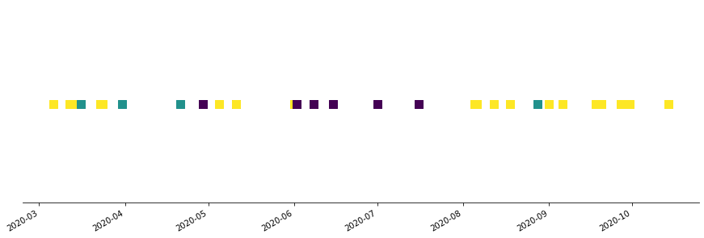

```python
#### 1.9
def calculate_types(group):
  row_count = group.shape[0]
  measure_type = []
  for i in range(row_count):
    if group["LOG_TYPE"].iloc[i] == "Phase-out measure":
      val = 0
    else:
      if group["IS_EXTENSION"].iloc[i]:
        val = 1
      else:
        val = 2
    measure_type.append(val)
  return measure_type

def show_timeline(group):
  row_count = group.shape[0]
  measure_type = calculate_types(group)

  fig, ax = plt.subplots(figsize=(15,5))
  ax.scatter(group["DATE_IMPLEMENTED"], [1]*len(group["DATE_IMPLEMENTED"]), c=measure_type, marker='s', s=100)
  fig.autofmt_xdate()
  ax.yaxis.set_visible(False)
  ax.spines['right'].set_visible(False)
  ax.spines['left'].set_visible(False)
  ax.spines['top'].set_visible(False)
  ax.xaxis.set_ticks_position('bottom')
  plt.show()

nl_group = country_groups.get_group("Netherlands")
show_timeline(nl_group)
```

Have a look at the countries with the highest estimated part of the population concurrently infected. Therefore, we divide the maximum current from the estimate by the population data. We use a log scale due to large differences and show countries with values above 1 per thousand.

### Data Processing + Feature Engineering

- Build df_prop and sort value
- Make plot disbution

```python
df_prog['mcpop'] = df_prog['maxcur'] / df_prog['popdata']
## Calculate the mcpopuplation per thousand.
df_progshow = df_prog[df_prog['mcpop'] > 1/1000].sort_values(by=['mcpop'])
df_progshow
```

|  | iso2 | cname | iso3 | ccont | popdata | rsquared | progress | final | start | peak | floor | beta | mu | maxcur | mcpop |
| --- | --- | --- | --- | --- | --- | --- | --- | --- | --- | --- | --- | --- | --- | --- | --- |
| 136 | RU | Russia | RUS | Europe | 145872260.0 | 0.980925 | 0.772697 | 8.469095e+05 | 2020-03-28 | 2020-05-25 | 2020-10-28 | 29.430769 | 146.103937 | 146829.948621 | 0.001007 |
| 112 | MV | Maldives | MDV | Asia | 530957.0 | 0.867354 | 0.866063 | 2.750378e+03 | 2020-03-31 | 2020-05-18 | 2020-09-28 | 24.671386 | 139.402536 | 566.581456 | 0.001067 |
| 142 | SG | Singapore | SGP | Asia | 5804343.0 | 0.739169 | 0.834456 | 5.287233e+04 | 2020-02-27 | 2020-05-20 | 2020-12-30 | 41.621119 | 140.554847 | 6512.274830 | 0.001122 |
| 164 | UK | United_Kingdom | GBR | Europe | 66647112.0 | 0.986508 | 0.979934 | 3.199020e+05 | 2020-03-12 | 2020-04-23 | 2020-08-17 | 21.294705 | 113.999117 | 76010.370985 | 0.001140 |
| 78 | IT | Italy | ITA | Europe | 60359546.0 | 0.989891 | 0.991791 | 2.427528e+05 | 2020-02-28 | 2020-04-01 | 2020-07-04 | 17.085021 | 92.484727 | 71177.390180 | 0.001179 |
| 79 | JE | Jersey | JEY | Europe | 107796.0 | 0.850194 | 0.971570 | 3.283344e+02 | 2020-03-15 | 2020-04-08 | 2020-06-15 | 12.305162 | 98.993702 | 130.452104 | 0.001210 |
| 141 | SE | Sweden | SWE | Europe | 10230185.0 | 0.802043 | 0.542392 | 1.284092e+05 | 2020-02-22 | 2020-06-07 | 2021-03-24 | 52.984713 | 158.960667 | 12453.349180 | 0.001217 |
| 109 | MS | Montserrat | MSF | America | 4991.0 | 0.354553 | 0.802430 | 1.370836e+01 | 2020-03-21 | 2020-04-10 | 2020-06-06 | 10.125194 | 100.858733 | 6.464036 | 0.001295 |
| 93 | LI | Liechtenstein | LIE | Europe | 38378.0 | 0.906384 | 1.007193 | 8.240727e+01 | 2020-03-11 | 2020-03-25 | 2020-05-04 | 6.915262 | 84.525142 | 52.584872 | 0.001370 |
| 138 | SA | Saudi_Arabia | SAU | Asia | 34268529.0 | 0.872429 | 0.387767 | 5.002959e+05 | 2020-03-18 | 2020-07-05 | 2021-05-02 | 53.688860 | 186.996146 | 47912.896292 | 0.001398 |
| 165 | US | United_States_of_America | USA | America | 329064917.0 | 0.788965 | 0.711695 | 3.774587e+06 | 2020-02-21 | 2020-05-15 | 2021-01-03 | 41.398348 | 135.920901 | 467378.211068 | 0.001420 |
| 60 | GI | Gibraltar | GIB | Europe | 33706.0 | 0.480978 | 0.502571 | 3.541760e+02 | 2020-02-07 | 2020-04-22 | 2020-11-17 | 36.900408 | 112.826211 | 49.137158 | 0.001458 |
| 22 | BY | Belarus | BLR | Europe | 9452409.0 | 0.989769 | 0.815510 | 7.654590e+04 | 2020-03-24 | 2020-05-20 | 2020-10-25 | 27.941710 | 140.535055 | 13963.104736 | 0.001477 |
| 101 | MC | Monaco | MCO | Europe | 33085.0 | 0.912742 | 0.953316 | 1.080439e+02 | 2020-03-13 | 2020-04-02 | 2020-05-31 | 10.076044 | 92.872183 | 51.158141 | 0.001546 |
| 27 | CH | Switzerland | CHE | Europe | 8544527.0 | 0.998270 | 1.034608 | 3.078558e+04 | 2020-03-09 | 2020-03-30 | 2020-05-31 | 10.522067 | 90.335356 | 14036.799117 | 0.001643 |
| 72 | IE | Ireland | IRL | Europe | 4904240.0 | 0.947582 | 0.993295 | 2.564898e+04 | 2020-03-14 | 2020-04-14 | 2020-07-13 | 15.242496 | 105.302753 | 8372.833932 | 0.001707 |
| 11 | BE | Belgium | BEL | Europe | 11455519.0 | 0.985602 | 1.043681 | 5.901994e+04 | 2020-03-08 | 2020-04-07 | 2020-07-02 | 14.656188 | 98.000510 | 19986.798608 | 0.001745 |
| 125 | PE | Peru | PER | America | 32510462.0 | 0.951495 | 0.646138 | 4.464392e+05 | 2020-03-20 | 2020-06-09 | 2021-01-27 | 39.557795 | 160.877037 | 57824.960763 | 0.001779 |
| 53 | FO | Faroe_Islands | FRO | Europe | 48677.0 | 0.971670 | 1.809599 | 1.033378e+02 | 2020-03-20 | 2020-03-28 | 2020-04-24 | 4.270050 | 88.329555 | 87.380376 | 0.001795 |
| 49 | ES | Spain | ESP | Europe | 46937060.0 | 0.991213 | 1.062136 | 2.350536e+05 | 2020-03-07 | 2020-04-01 | 2020-06-13 | 12.085313 | 91.809173 | 94919.594963 | 0.002022 |
| 97 | LU | Luxembourg | LUX | Europe | 613894.0 | 0.495748 | 0.667194 | 6.512345e+03 | 2020-02-11 | 2020-04-04 | 2020-09-06 | 25.703482 | 94.849206 | 1288.964253 | 0.002100 |
| 64 | GT | Guatemala | GTM | America | 17581476.0 | 0.525466 | 0.026375 | 6.561756e+05 | 2020-04-19 | 2020-11-11 | NaT | 98.714536 | 316.019265 | 37575.082055 | 0.002137 |
| 74 | IM | Isle_of_Man | IMN | Europe | 84589.0 | 0.913950 | 0.934044 | 3.597262e+02 | 2020-03-22 | 2020-04-10 | 2020-06-04 | 8.815173 | 100.645801 | 190.464594 | 0.002252 |
| 88 | KW | Kuwait | KWT | Asia | 4207077.0 | 0.734354 | 0.452131 | 1.036670e+05 | 2020-03-08 | 2020-07-03 | 2021-06-09 | 55.835434 | 185.339632 | 9551.523696 | 0.002270 |
| 77 | IS | Iceland | ISL | Europe | 356991.0 | 0.833255 | 0.896730 | 2.059706e+03 | 2020-03-03 | 2020-03-28 | 2020-06-10 | 11.877406 | 87.848517 | 844.757264 | 0.002366 |
| 52 | FK | Falkland_Islands_(Malvinas) | FLK | America | 3372.0 | 0.522047 | 0.981258 | 1.324830e+01 | 2020-03-30 | 2020-04-14 | 2020-05-28 | 6.978082 | 104.612256 | 8.396928 | 0.002490 |
| 58 | GG | Guernsey | GGY | Europe | 64468.0 | 0.922990 | 0.997937 | 2.525210e+02 | 2020-03-22 | 2020-04-05 | 2020-05-19 | 6.865693 | 96.085161 | 161.917075 | 0.002512 |
| 124 | PA | Panama | PAN | America | 4246440.0 | 0.387630 | 0.180947 | 1.854335e+05 | 2020-02-17 | 2020-08-20 | NaT | 87.392145 | 232.994758 | 11212.310443 | 0.002640 |
| 32 | CO | Colombia | COL | America | 50339443.0 | 0.626253 | 0.037635 | 2.452679e+06 | 2020-03-31 | 2020-11-06 | NaT | 103.702881 | 310.657031 | 134511.476384 | 0.002672 |
| 19 | BR | Brazil | BRA | America | 211049519.0 | 0.948316 | 0.187430 | 7.679768e+06 | 2020-03-24 | 2020-08-09 | NaT | 64.958774 | 221.984950 | 611655.602812 | 0.002898 |
| 155 | TC | Turks_and_Caicos_islands | TCA | America | 38194.0 | 0.071086 | 0.011810 | 2.428209e+03 | 2020-03-02 | 2021-02-01 | NaT | 157.122787 | 398.109455 | 116.531335 | 0.003051 |
| 63 | GQ | Equatorial_Guinea | GNQ | Africa | 1355982.0 | 0.154025 | 0.021841 | 8.088000e+04 | 2020-03-22 | 2020-11-14 | NaT | 110.662662 | 319.075630 | 4261.075586 | 0.003142 |
| 168 | VA | Holy_See | VAT | Europe | 815.0 | 0.274020 | 0.319258 | 3.750349e+01 | 2019-12-31 | 2020-05-20 | NaT | 65.906989 | 141.452809 | 2.931769 | 0.003597 |
| 17 | BO | Bolivia | BOL | America | 11513102.0 | 0.856749 | 0.047016 | 6.911157e+05 | 2020-04-05 | 2020-10-13 | NaT | 88.624520 | 287.439506 | 42262.397104 | 0.003671 |
| 0 | AD | Andorra | AND | Europe | 76177.0 | 0.405009 | 0.292502 | 2.922351e+03 | 2020-01-24 | 2020-05-11 | 2021-04-09 | 50.031088 | 132.358777 | 299.932303 | 0.003937 |
| 146 | SM | San_Marino | SMR | Europe | 34453.0 | 0.767452 | 0.837871 | 8.330633e+02 | 2020-02-11 | 2020-04-10 | 2020-10-11 | 27.027059 | 101.096695 | 157.004025 | 0.004557 |
| 133 | QA | Qatar | QAT | Asia | 2832071.0 | 0.917351 | 0.663761 | 1.461328e+05 | 2020-03-11 | 2020-06-08 | 2021-03-22 | 40.024027 | 159.737339 | 18709.569356 | 0.006606 |
| 39 | DJ | Djibouti | DJI | Africa | 973557.0 | 0.018860 | 0.019178 | 1.682719e+05 | 2020-01-22 | 2021-01-24 | NaT | 162.941626 | 390.467098 | 7750.638638 | 0.007961 |
| 14 | BH | Bahrain | BHR | Asia | 1641164.0 | 0.716305 | 0.112563 | 2.322946e+05 | 2020-02-19 | 2020-09-19 | NaT | 94.032720 | 262.570708 | 13327.037814 | 0.008120 |
| 123 | OM | Oman | OMN | Asia | 4974992.0 | 0.573913 | 0.055722 | 7.014430e+05 | 2020-03-19 | 2020-10-10 | NaT | 90.253522 | 283.574516 | 42144.433461 | 0.008471 |
| 29 | CL | Chile | CHL | America | 18952035.0 | 0.487320 | 0.080035 | 3.363133e+06 | 2020-03-05 | 2020-09-28 | NaT | 90.533420 | 272.147747 | 200275.426376 | 0.010567 |
| 4 | AM | Armenia | ARM | Europe | 2957728.0 | 0.366437 | 0.014079 | 1.346352e+06 | 2020-02-26 | 2021-01-23 | NaT | 139.939784 | 389.394607 | 68107.927888 | 0.023027 |

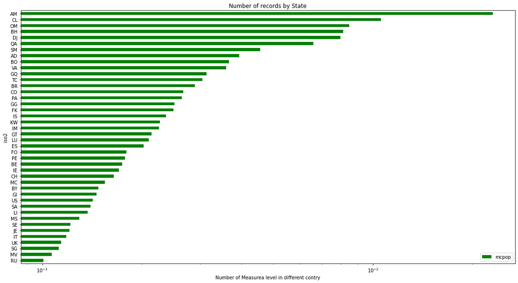

```python
# Creating distribution
x = 'iso2'
y = 'mcpop'
# Set color
my_colors = 'Green'
# axs.hist(x, bins = n_bins)
fig = df_progshow.plot(
    x, y, kind='barh', logx=True, figsize=(19, 10), grid=False, color=my_colors, label='mcpop', )

## Creating name
plt.xlabel('Number of Measurea level in different contry')
plt.title('Number of records by State')

plt.show()
```

The log of infected seems a good initial measure, so we define it as target.

```python
df_prog['target'] = np.log10(df_prog['mcpop'])
df_prog['target'].describe()
#make the normal target for the
```

```
count    176.000000
mean      -3.529878
std        0.684149
min       -4.807437
25%       -4.104853
50%       -3.541673
75%       -3.013171
max       -1.637761
Name: target, dtype: float64
```

For looking at country behavior we try the ACAPS government measures dataset.

```python
df_meas = pd.read_excel('acaps_covid19_government_measures_dataset_0.xlsx', sheet_name='Dataset')
df_meas

# df_meas = pd.read_excel('acaps_covid19_government_measures_dataset_0.xlsx', sheet_name='Data')
# df_meas
```

|  | ID | ISO | COUNTRY | REGION | ADMIN_LEVEL_NAME | PCODE | LOG_TYPE | CATEGORY | MEASURE | TARGETED_POP_GROUP | COMMENTS | NON_COMPLIANCE | DATE_IMPLEMENTED | SOURCE | SOURCE_TYPE | LINK | ENTRY_DATE | Alternative source |
| --- | --- | --- | --- | --- | --- | --- | --- | --- | --- | --- | --- | --- | --- | --- | --- | --- | --- | --- |
| 0 | 4245 | AFG | Afghanistan | Asia | NaN | NaN | Introduction / extension of measures | Public health measures | Awareness campaigns | NaN | MoPH begins announcements on their facebook to... | NaN | 2020-01-24 | Afghanistan MoPH | Government | https://www.facebook.com/af.moph/posts/1005130... | 2020-04-07 | NaN |
| 1 | 4246 | AFG | Afghanistan | Asia | NaN | NaN | Introduction / extension of measures | Public health measures | Health screenings in airports and border cross... | checked | Health teams at airports will check passengers... | NaN | 2020-01-26 | Afghanistan MoPH | Government | https://www.facebook.com/af.moph/posts/1006458... | 2020-04-07 | NaN |
| 2 | 4247 | AFG | Afghanistan | Asia | NaN | NaN | Introduction / extension of measures | Movement restrictions | International flights suspension | checked | Flights to China are suspended. | NaN | 2020-01-27 | Afghanistan MoPH | Government | https://www.facebook.com/af.moph/photos/a.4625... | 2020-04-07 | NaN |
| 3 | 4248 | AFG | Afghanistan | Asia | NaN | NaN | Introduction / extension of measures | Public health measures | Health screenings in airports and border cross... | NaN | Health screenings of all passengers at airports. | NaN | 2020-01-27 | Afghanistan MoPH | Government | https://www.facebook.com/af.moph/photos/a.4625... | 2020-04-07 | NaN |
| 4 | 23 | AFG | Afghanistan | Asia | NaN | NaN | Introduction / extension of measures | Movement restrictions | Border checks | checked | All China and Iran nationals | NaN | 2020-02-01 | US Embassy | Government | https://af.usembassy.gov/covid-19-information/ | 2020-03-14 | NaN |
| 5 | 4249 | AFG | Afghanistan | Asia | Kabul | NaN | Introduction / extension of measures | Public health measures | Strengthening the public health system | checked | the ministry has prepared 100 bed to control t... | NaN | 2020-02-02 | Afghanistan MoPH | Government | https://www.facebook.com/af.moph/posts/1011701... | 2020-04-07 | NaN |
| 6 | 4250 | AFG | Afghanistan | Asia | NaN | NaN | Introduction / extension of measures | Public health measures | Isolation and quarantine policies | NaN | NaN | NaN | 2020-02-02 | Afghanistan MoPH | Government | https://www.facebook.com/af.moph/posts/1011701... | 2020-04-07 | NaN |
| 7 | 4252 | AFG | Afghanistan | Asia | NaN | NaN | Introduction / extension of measures | Public health measures | Strengthening the public health system | NaN | The Ministry of public health has created the ... | NaN | 2020-02-04 | Afghanistan MoPH | Government | https://www.facebook.com/af.moph/posts/1013057... | 2020-04-07 | NaN |
| 8 | 4251 | AFG | Afghanistan | Asia | NaN | NaN | Introduction / extension of measures | Public health measures | Awareness campaigns | NaN | Print, publishing and sending advertising mate... | NaN | 2020-02-04 | Afghanistan MoPH | Government | https://www.facebook.com/af.moph/posts/1013023... | 2020-04-07 | NaN |
| 9 | 4253 | AFG | Afghanistan | Asia | NaN | NaN | Introduction / extension of measures | Governance and socio-economic measures | Emergency administrative structures activated ... | checked | review list of equipment, medical requirements... | NaN | 2020-02-06 | Afghanistan MoPH | Government | https://www.facebook.com/af.moph/posts/1014455... | 2020-04-07 | NaN |
| 10 | 4254 | AFG | Afghanistan | Asia | NaN | NaN | Introduction / extension of measures | Public health measures | Awareness campaigns | checked | the launch of education programs for doctors t... | NaN | 2020-02-08 | Afghanistan MoPH | Government | https://www.facebook.com/af.moph/posts/1015946... | 2020-04-07 | NaN |
| 11 | 3 | AFG | Afghanistan | Asia | NaN | NaN | Introduction / extension of measures | Public health measures | Awareness campaigns | NaN | NaN | NaN | 2020-02-12 | Ministry of Health | Government | https://moph.gov.af/en/moph-held-emergency-mee... | 2020-03-14 | NaN |
| 12 | 2 | AFG | Afghanistan | Asia | Kabul | NaN | Introduction / extension of measures | Public health measures | Isolation and quarantine policies | NaN | NaN | NaN | 2020-02-12 | Ministry of Health | Government | https://moph.gov.af/en/moph-held-emergency-mee... | 2020-03-14 | NaN |
| 13 | 4 | AFG | Afghanistan | Asia | NaN | NaN | Introduction / extension of measures | Governance and socio-economic measures | Emergency administrative structures activated ... | NaN | NaN | NaN | 2020-02-12 | Ministry of Health | Government | https://moph.gov.af/en/moph-held-emergency-mee... | 2020-03-14 | NaN |
| 14 | 1 | AFG | Afghanistan | Asia | NaN | NaN | Introduction / extension of measures | Public health measures | Health screenings in airports and border cross... | NaN | NaN | NaN | 2020-02-12 | Ministry of Health | Government | https://moph.gov.af/en/moph-held-emergency-mee... | 2020-03-14 | NaN |
| 15 | 4255 | AFG | Afghanistan | Asia | Kabul | NaN | Introduction / extension of measures | Public health measures | Isolation and quarantine policies | checked | Established specific areas for quarantine in K... | NaN | 2020-02-12 | Afghanistan MoPH | Government | http://tinyurl.com/rsfhsz9 | 2020-04-07 | http://tinyurl.com/twpqsek |
| 16 | 4256 | AFG | Afghanistan | Asia | NaN | NaN | Introduction / extension of measures | Movement restrictions | Surveillance and monitoring | NaN | Monitoring and surveillance increased at natio... | NaN | 2020-02-13 | Afghanistan MoPH | Government | https://www.facebook.com/af.moph/posts/1019580... | 2020-04-07 | NaN |
| 17 | 4257 | AFG | Afghanistan | Asia | NaN | NaN | Introduction / extension of measures | Public health measures | Other public health measures enforced | NaN | strengthen the screened teams in the air, bord... | NaN | 2020-02-20 | Afghanistan MoPH | Government | https://www.facebook.com/af.moph/posts/1025043... | 2020-04-07 | NaN |
| 18 | 4258 | AFG | Afghanistan | Asia | NaN | NaN | Introduction / extension of measures | Public health measures | Strengthening the public health system | checked | Prioritizing disinfecting of health centers an... | NaN | 2020-02-22 | Afghanistan MoPH | Government | https://www.facebook.com/af.moph/posts/1026689... | 2020-04-07 | NaN |
| 19 | 6 | AFG | Afghanistan | Asia | NaN | NaN | Introduction / extension of measures | Movement restrictions | Border closure | NaN | Closure of borders with Iran | NaN | 2020-02-24 | Guardian | Media | https://www.theguardian.com/global-development... | 2020-03-14 | NaN |
| 20 | 4262 | AFG | Afghanistan | Asia | NaN | NaN | Introduction / extension of measures | Public health measures | General recommendations | checked | Those who have traveled to Iran in the last mo... | NaN | 2020-02-24 | Afghanistan MoPH | Government | https://www.facebook.com/af.moph/posts/1028193... | 2020-04-07 | NaN |
| 21 | 4260 | AFG | Afghanistan | Asia | Herat Province | NaN | Introduction / extension of measures | Governance and socio-economic measures | State of emergency declared | checked | State of emergency in Herat province. | NaN | 2020-02-24 | Afghanistan MoPH | Government | https://www.facebook.com/af.moph/posts/1028193... | 2020-04-07 | NaN |
| 22 | 4261 | AFG | Afghanistan | Asia | NaN | NaN | Introduction / extension of measures | Public health measures | Awareness campaigns | NaN | Awareness campaign expands to include avoiding... | NaN | 2020-02-24 | Afghanistan MoPH | Government | https://www.facebook.com/af.moph/posts/1028193... | 2020-04-07 | NaN |
| 23 | 4259 | AFG | Afghanistan | Asia | NaN | NaN | Introduction / extension of measures | Movement restrictions | Domestic travel restrictions | checked | Avoid domestic travel to the Herat province. | NaN | 2020-02-24 | Afghanistan MoPH | Government | https://www.facebook.com/af.moph/posts/1028193... | 2020-04-07 | NaN |
| 24 | 10 | AFG | Afghanistan | Asia | Herat | NaN | Introduction / extension of measures | Social distancing | Limit public gatherings | NaN | all public gatherings banned | NaN | 2020-03-01 | OCHA | UN | https://reliefweb.int/sites/reliefweb.int/file... | 2020-03-14 | NaN |
| 25 | 12 | AFG | Afghanistan | Asia | NaN | NaN | Introduction / extension of measures | Public health measures | Strengthening the public health system | NaN | NaN | NaN | 2020-03-01 | OCHA | UN | https://reliefweb.int/sites/reliefweb.int/file... | 2020-03-14 | NaN |
| 26 | 17 | AFG | Afghanistan | Asia | NaN | NaN | Introduction / extension of measures | Governance and socio-economic measures | Limit product imports/exports | NaN | Food imports from Iran and Afghanistan has bee... | NaN | 2020-03-01 | US Embassy | Government | https://af.usembassy.gov/covid-19-information/ | 2020-03-14 | NaN |
| 27 | 8 | AFG | Afghanistan | Asia | Herat | NaN | Introduction / extension of measures | Social distancing | Schools closure | NaN | NaN | NaN | 2020-03-01 | OCHA | UN | https://reliefweb.int/sites/reliefweb.int/file... | 2020-03-14 | NaN |
| 28 | 4263 | AFG | Afghanistan | Asia | Midday Province | NaN | Introduction / extension of measures | Movement restrictions | Border checks | checked | Increased the screened teams on the ground and... | NaN | 2020-03-01 | Afghanistan MoPH | Government | https://www.facebook.com/af.moph/posts/1030421... | 2020-04-07 | NaN |
| 29 | 4264 | AFG | Afghanistan | Asia | NaN | NaN | Introduction / extension of measures | Public health measures | Strengthening the public health system | checked | Medical students are now allowed to practice, ... | NaN | 2020-03-02 | Afghanistan MoPH | Government | https://www.facebook.com/af.moph/posts/1033521... | 2020-04-07 | NaN |
| ... | ... | ... | ... | ... | ... | ... | ... | ... | ... | ... | ... | ... | ... | ... | ... | ... | ... | ... |
| 23893 | 1960 | ZWE | Zimbabwe | Africa | NaN | NaN | Introduction / extension of measures | Public health measures | Isolation and quarantine policies | NaN | All our returning residents will be subjected ... | Not applicable | 2020-03-24 | The Herald | Media | https://www.herald.co.zw/new-measures-to-stop-... | 2020-03-24 | NaN |
| 23894 | 1957 | ZWE | Zimbabwe | Africa | NaN | NaN | Introduction / extension of measures | Social distancing | Closure of businesses and public services | NaN | Government has put a blanket ban on gathering ... | Up to detention | 2020-03-24 | Ministry of Health | Social media | https://twitter.com/MoHCCZim/status/1242180289... | 2020-03-24 | NaN |
| 23895 | 1956 | ZWE | Zimbabwe | Africa | NaN | NaN | Introduction / extension of measures | Movement restrictions | Border closure | NaN | Government has decided to ban all non-essentia... | Not applicable | 2020-03-24 | Ministry of Health | Social media | https://twitter.com/MoHCCZim/status/1242180289... | 2020-03-24 | NaN |
| 23896 | 1958 | ZWE | Zimbabwe | Africa | NaN | NaN | Introduction / extension of measures | Social distancing | Limit public gatherings | NaN | All public gatherings should not exceed 50 per... | Up to detention | 2020-03-24 | Ministry of Health | Social media | https://twitter.com/MoHCCZim/status/1242180289... | 2020-03-24 | NaN |
| 23897 | 1961 | ZWE | Zimbabwe | Africa | NaN | NaN | Introduction / extension of measures | Public health measures | Health screenings in airports and border cross... | NaN | All our returning residents will be subjected ... | Not applicable | 2020-03-24 | The Herald | Media | https://www.herald.co.zw/new-measures-to-stop-... | 2020-03-24 | NaN |
| 23898 | 2956 | ZWE | Zimbabwe | Africa | NaN | NaN | Introduction / extension of measures | Lockdown | Partial lockdown | NaN | Zimbabwe will go into lockdown for three weeks... | Arrest/Detention | 2020-03-30 | Africa News | Media | https://www.africanews.com/2020/03/27/coronavi... | 2020-03-28 | https://www.bbc.com/news/topics/crr7mlg0rpvt/z... |
| 23899 | 4303 | ZWE | Zimbabwe | Africa | NaN | NaN | Phase-out measure | Public health measures | Other public health measures enforced | NaN | Zimbabwe reversed a ban on the sale of alcohol... | Not applicable | 2020-04-03 | BBC | Media | https://www.bbc.com/news/topics/crr7mlg0rpvt/z... | 2020-04-07 | NaN |
| 23900 | 5421 | ZWE | Zimbabwe | Africa | NaN | NaN | Introduction / extension of measures | Governance and socio-economic measures | Emergency administrative structures activated ... | NaN | The Ministry has launched a tollfree helpline ... | Not applicable | 2020-04-14 | Ministry of Information | Social media | https://twitter.com/MinOfInfoZW/status/1250037... | 2020-04-15 | NaN |
| 23901 | 5420 | ZWE | Zimbabwe | Africa | NaN | NaN | Introduction / extension of measures | Public health measures | Testing policy | NaN | Zimbabwe begins mass testing with the aim to e... | Not applicable | 2020-04-15 | BBC | Media | https://www.bbc.com/news/world/africa/live | 2020-04-15 | NaN |
| 23902 | 7352 | ZWE | Zimbabwe | Africa | NaN | NaN | Phase-out measure | Social distancing | Limit public gatherings | checked | The mining sector allowed to scale up operatio... | Not applicable | 2020-04-19 | Ministry of Information | Social media | https://twitter.com/MinOfInfoZW | 2020-04-24 | NaN |
| 23903 | 7351 | ZWE | Zimbabwe | Africa | NaN | NaN | Phase-out measure | Social distancing | Closure of businesses and public services | NaN | Limited manufacturing operations to resume.Ins... | Not applicable | 2020-04-19 | Ministry of Information | Social media | https://twitter.com/MinOfInfoZW | 2020-04-24 | NaN |
| 23904 | 6425 | ZWE | Zimbabwe | Africa | NaN | NaN | Introduction / extension of measures | Lockdown | Partial lockdown | NaN | Lockdown due to end on the 20th April will be ... | Up to detention | 2020-04-20 | BBC | Media | https://www.bbc.com/news/live/world-africa-476... | 2020-04-20 | NaN |
| 23905 | 7353 | ZWE | Zimbabwe | Africa | NaN | NaN | Introduction / extension of measures | Governance and socio-economic measures | Economic measures | NaN | A price moratorium has been introduced on good... | Not available | 2020-04-22 | Ministry of Information | Social media | https://twitter.com/MinOfInfoZW/status/1252946... | 2020-04-24 | NaN |
| 23906 | 7354 | ZWE | Zimbabwe | Africa | NaN | NaN | Introduction / extension of measures | Governance and socio-economic measures | Emergency administrative structures activated ... | NaN | As of 24 April 2020, four (4) more laboratorie... | Not applicable | 2020-04-24 | Ministry of Information | Social media | https://twitter.com/MinOfInfoZW | 2020-04-24 | NaN |
| 23907 | 8390 | ZWE | Zimbabwe | Africa | NaN | NaN | Introduction / extension of measures | Governance and socio-economic measures | Economic measures | NaN | Both residential & commercial properties will ... | Not applicable | 2020-04-28 | Ministry of Information | Social media | https://twitter.com/MinOfInfoZW/status/1255190... | 2020-04-30 | NaN |
| 23908 | 8902 | ZWE | Zimbabwe | Africa | NaN | NaN | Introduction / extension of measures | Social distancing | Changes in prison-related policies | checked | Zimbabwe frees all female prisoners save those... | Not applicable | 2020-05-01 | BBC | Media | https://www.bbc.com/news/world/africa/live | 2020-05-04 | NaN |
| 23909 | 11772 | ZWE | Zimbabwe | Africa | NaN | NaN | Introduction / extension of measures | Public health measures | Requirement to wear protective gear in public | NaN | The government of Zimbabwe has officially made... | Arrest/Detention | 2020-05-04 | Africa News | Media | https://www.africanews.com/2020/05/10/zimbabwe... | 2020-05-25 | https://www.garda.com/crisis24/news-alerts/339... |
| 23910 | 11773 | ZWE | Zimbabwe | Africa | NaN | NaN | Introduction / extension of measures | Lockdown | Partial lockdown | NaN | Zimbabwe extends lockdown until May 15th | Not available | 2020-05-04 | Garda | Media | https://www.garda.com/crisis24/news-alerts/339... | 2020-05-25 | NaN |
| 23911 | 10454 | ZWE | Zimbabwe | Africa | NaN | NaN | Phase-out measure | Social distancing | Limit public gatherings | NaN | Companies are now permitted to open, pending a... | Not applicable | 2020-05-05 | Ministry of Informatino | Social media | https://twitter.com/MinOfInfoZW/status/1257764... | 2020-05-13 | NaN |
| 23912 | 11769 | ZWE | Zimbabwe | Africa | NaN | NaN | Phase-out measure | Social distancing | Closure of businesses and public services | NaN | The Gvmt extends opening times for commercial ... | Not applicable | 2020-05-16 | Zimbabwe Government | Government | http://www.zim.gov.zw/index.php/en/news-room/l... | 2020-05-25 | NaN |
| 23913 | 11771 | ZWE | Zimbabwe | Africa | NaN | NaN | Introduction / extension of measures | Lockdown | Partial lockdown | NaN | Partial lockdown (level 2) extended indefinite... | Not available | 2020-05-17 | Zimbabwe Government | Government | http://www.zim.gov.zw/index.php/en/news-room/l... | 2020-05-25 | https://zw.usembassy.gov/covid-19-information-2/ |
| 23914 | 11775 | ZWE | Zimbabwe | Africa | NaN | NaN | Phase-out measure | Social distancing | Limit public gatherings | NaN | Athletes taking part in low-risk sports, inclu... | Not applicable | 2020-05-17 | Zimbabwe Government | Government | http://www.zim.gov.zw/index.php/en/news-room/l... | 2020-05-25 | NaN |
| 23915 | 11774 | ZWE | Zimbabwe | Africa | NaN | NaN | Phase-out measure | Social distancing | Limit public gatherings | NaN | Outdoor exercises like walking or jogging or c... | Not applicable | 2020-05-17 | Zimbabwe Government | Government | http://www.zim.gov.zw/index.php/en/news-room/l... | 2020-05-25 | NaN |
| 23916 | 11770 | ZWE | Zimbabwe | Africa | NaN | NaN | Phase-out measure | Social distancing | Limit public gatherings | NaN | Cabinet has approved the resumption of low ris... | Not applicable | 2020-05-21 | Ministry of Information | Social media | https://twitter.com/MinOfInfoZW/status/1263565... | 2020-05-25 | NaN |
| 23917 | 13722 | ZWE | Zimbabwe | Africa | NaN | NaN | Introduction / extension of measures | Movement restrictions | Surveillance and monitoring | NaN | Everyone transiting through Zimbabwe should ha... | Not available | 2020-06-09 | Ministry of Information | Social media | https://twitter.com/MinOfInfoZW/status/1270378... | 2020-06-13 | NaN |
| 23918 | 13724 | ZWE | Zimbabwe | Africa | NaN | NaN | Introduction / extension of measures | Movement restrictions | Surveillance and monitoring | checked | Identification/travel documents of returness w... | Not available | 2020-06-09 | Ministry of Information | Social media | https://twitter.com/MinOfInfoZW/status/1270378... | 2020-06-13 | NaN |
| 23919 | 14735 | ZWE | Zimbabwe | Africa | NaN | NaN | Phase-out measure | Social distancing | Closure of businesses and public services | checked | Safari Operators for local hunting only and Na... | Not applicable | 2020-06-30 | Ministry of Information | Social media | https://twitter.com/MinOfInfoZW/status/1278043... | 2020-07-03 | NaN |
| 23920 | 14734 | ZWE | Zimbabwe | Africa | NaN | NaN | Phase-out measure | Social distancing | Closure of businesses and public services | checked | Restaurants now allowed to serve sit-in meals ... | Not applicable | 2020-06-30 | Ministry of Information | Social media | https://twitter.com/MinOfInfoZW/status/1278043... | 2020-07-03 | NaN |
| 23921 | 13723 | ZWE | Zimbabwe | Africa | NaN | NaN | Phase-out measure | Social distancing | Schools closure | NaN | the re-opening of schools be moved from the pr... | Not applicable | 2020-07-28 | Ministry of Information | Social media | https://twitter.com/MinOfInfoZW/status/1270378... | 2020-06-13 | NaN |
| 23922 | 138074 | ZWE | Zimbabwe | Africa | NaN | NaN | Introduction / extension of measures | Public health measures | Health screenings in airports and border cross... | checked | Passengers will undergo temperature checks at ... | Not Available | 2020-10-01 | Emirates | Media | https://www.emirates.com/za/english/help/faqs/... | 2020-10-30 | NaN |

23923 rows × 18 columns

The dataset contains both start and end of measures, so let's see how they are coded.

```python
print(df_meas['LOG_TYPE'].unique())
df_meas = df_meas[df_meas['LOG_TYPE'] == 'Introduction / extension of measures']
df_meas
```

```
['Introduction / extension of measures' 'Phase-out measure']
```

|  | ID | ISO | COUNTRY | REGION | ADMIN_LEVEL_NAME | PCODE | LOG_TYPE | CATEGORY | MEASURE | TARGETED_POP_GROUP | COMMENTS | NON_COMPLIANCE | DATE_IMPLEMENTED | SOURCE | SOURCE_TYPE | LINK | ENTRY_DATE | Alternative source |
| --- | --- | --- | --- | --- | --- | --- | --- | --- | --- | --- | --- | --- | --- | --- | --- | --- | --- | --- |
| 0 | 4245 | AFG | Afghanistan | Asia | NaN | NaN | Introduction / extension of measures | Public health measures | Awareness campaigns | NaN | MoPH begins announcements on their facebook to... | NaN | 2020-01-24 | Afghanistan MoPH | Government | https://www.facebook.com/af.moph/posts/1005130... | 2020-04-07 | NaN |
| 1 | 4246 | AFG | Afghanistan | Asia | NaN | NaN | Introduction / extension of measures | Public health measures | Health screenings in airports and border cross... | checked | Health teams at airports will check passengers... | NaN | 2020-01-26 | Afghanistan MoPH | Government | https://www.facebook.com/af.moph/posts/1006458... | 2020-04-07 | NaN |
| 2 | 4247 | AFG | Afghanistan | Asia | NaN | NaN | Introduction / extension of measures | Movement restrictions | International flights suspension | checked | Flights to China are suspended. | NaN | 2020-01-27 | Afghanistan MoPH | Government | https://www.facebook.com/af.moph/photos/a.4625... | 2020-04-07 | NaN |
| 3 | 4248 | AFG | Afghanistan | Asia | NaN | NaN | Introduction / extension of measures | Public health measures | Health screenings in airports and border cross... | NaN | Health screenings of all passengers at airports. | NaN | 2020-01-27 | Afghanistan MoPH | Government | https://www.facebook.com/af.moph/photos/a.4625... | 2020-04-07 | NaN |
| 4 | 23 | AFG | Afghanistan | Asia | NaN | NaN | Introduction / extension of measures | Movement restrictions | Border checks | checked | All China and Iran nationals | NaN | 2020-02-01 | US Embassy | Government | https://af.usembassy.gov/covid-19-information/ | 2020-03-14 | NaN |
| 5 | 4249 | AFG | Afghanistan | Asia | Kabul | NaN | Introduction / extension of measures | Public health measures | Strengthening the public health system | checked | the ministry has prepared 100 bed to control t... | NaN | 2020-02-02 | Afghanistan MoPH | Government | https://www.facebook.com/af.moph/posts/1011701... | 2020-04-07 | NaN |
| 6 | 4250 | AFG | Afghanistan | Asia | NaN | NaN | Introduction / extension of measures | Public health measures | Isolation and quarantine policies | NaN | NaN | NaN | 2020-02-02 | Afghanistan MoPH | Government | https://www.facebook.com/af.moph/posts/1011701... | 2020-04-07 | NaN |
| 7 | 4252 | AFG | Afghanistan | Asia | NaN | NaN | Introduction / extension of measures | Public health measures | Strengthening the public health system | NaN | The Ministry of public health has created the ... | NaN | 2020-02-04 | Afghanistan MoPH | Government | https://www.facebook.com/af.moph/posts/1013057... | 2020-04-07 | NaN |
| 8 | 4251 | AFG | Afghanistan | Asia | NaN | NaN | Introduction / extension of measures | Public health measures | Awareness campaigns | NaN | Print, publishing and sending advertising mate... | NaN | 2020-02-04 | Afghanistan MoPH | Government | https://www.facebook.com/af.moph/posts/1013023... | 2020-04-07 | NaN |
| 9 | 4253 | AFG | Afghanistan | Asia | NaN | NaN | Introduction / extension of measures | Governance and socio-economic measures | Emergency administrative structures activated ... | checked | review list of equipment, medical requirements... | NaN | 2020-02-06 | Afghanistan MoPH | Government | https://www.facebook.com/af.moph/posts/1014455... | 2020-04-07 | NaN |
| 10 | 4254 | AFG | Afghanistan | Asia | NaN | NaN | Introduction / extension of measures | Public health measures | Awareness campaigns | checked | the launch of education programs for doctors t... | NaN | 2020-02-08 | Afghanistan MoPH | Government | https://www.facebook.com/af.moph/posts/1015946... | 2020-04-07 | NaN |
| 11 | 3 | AFG | Afghanistan | Asia | NaN | NaN | Introduction / extension of measures | Public health measures | Awareness campaigns | NaN | NaN | NaN | 2020-02-12 | Ministry of Health | Government | https://moph.gov.af/en/moph-held-emergency-mee... | 2020-03-14 | NaN |
| 12 | 2 | AFG | Afghanistan | Asia | Kabul | NaN | Introduction / extension of measures | Public health measures | Isolation and quarantine policies | NaN | NaN | NaN | 2020-02-12 | Ministry of Health | Government | https://moph.gov.af/en/moph-held-emergency-mee... | 2020-03-14 | NaN |
| 13 | 4 | AFG | Afghanistan | Asia | NaN | NaN | Introduction / extension of measures | Governance and socio-economic measures | Emergency administrative structures activated ... | NaN | NaN | NaN | 2020-02-12 | Ministry of Health | Government | https://moph.gov.af/en/moph-held-emergency-mee... | 2020-03-14 | NaN |
| 14 | 1 | AFG | Afghanistan | Asia | NaN | NaN | Introduction / extension of measures | Public health measures | Health screenings in airports and border cross... | NaN | NaN | NaN | 2020-02-12 | Ministry of Health | Government | https://moph.gov.af/en/moph-held-emergency-mee... | 2020-03-14 | NaN |
| 15 | 4255 | AFG | Afghanistan | Asia | Kabul | NaN | Introduction / extension of measures | Public health measures | Isolation and quarantine policies | checked | Established specific areas for quarantine in K... | NaN | 2020-02-12 | Afghanistan MoPH | Government | http://tinyurl.com/rsfhsz9 | 2020-04-07 | http://tinyurl.com/twpqsek |
| 16 | 4256 | AFG | Afghanistan | Asia | NaN | NaN | Introduction / extension of measures | Movement restrictions | Surveillance and monitoring | NaN | Monitoring and surveillance increased at natio... | NaN | 2020-02-13 | Afghanistan MoPH | Government | https://www.facebook.com/af.moph/posts/1019580... | 2020-04-07 | NaN |
| 17 | 4257 | AFG | Afghanistan | Asia | NaN | NaN | Introduction / extension of measures | Public health measures | Other public health measures enforced | NaN | strengthen the screened teams in the air, bord... | NaN | 2020-02-20 | Afghanistan MoPH | Government | https://www.facebook.com/af.moph/posts/1025043... | 2020-04-07 | NaN |
| 18 | 4258 | AFG | Afghanistan | Asia | NaN | NaN | Introduction / extension of measures | Public health measures | Strengthening the public health system | checked | Prioritizing disinfecting of health centers an... | NaN | 2020-02-22 | Afghanistan MoPH | Government | https://www.facebook.com/af.moph/posts/1026689... | 2020-04-07 | NaN |
| 19 | 6 | AFG | Afghanistan | Asia | NaN | NaN | Introduction / extension of measures | Movement restrictions | Border closure | NaN | Closure of borders with Iran | NaN | 2020-02-24 | Guardian | Media | https://www.theguardian.com/global-development... | 2020-03-14 | NaN |
| 20 | 4262 | AFG | Afghanistan | Asia | NaN | NaN | Introduction / extension of measures | Public health measures | General recommendations | checked | Those who have traveled to Iran in the last mo... | NaN | 2020-02-24 | Afghanistan MoPH | Government | https://www.facebook.com/af.moph/posts/1028193... | 2020-04-07 | NaN |
| 21 | 4260 | AFG | Afghanistan | Asia | Herat Province | NaN | Introduction / extension of measures | Governance and socio-economic measures | State of emergency declared | checked | State of emergency in Herat province. | NaN | 2020-02-24 | Afghanistan MoPH | Government | https://www.facebook.com/af.moph/posts/1028193... | 2020-04-07 | NaN |
| 22 | 4261 | AFG | Afghanistan | Asia | NaN | NaN | Introduction / extension of measures | Public health measures | Awareness campaigns | NaN | Awareness campaign expands to include avoiding... | NaN | 2020-02-24 | Afghanistan MoPH | Government | https://www.facebook.com/af.moph/posts/1028193... | 2020-04-07 | NaN |
| 23 | 4259 | AFG | Afghanistan | Asia | NaN | NaN | Introduction / extension of measures | Movement restrictions | Domestic travel restrictions | checked | Avoid domestic travel to the Herat province. | NaN | 2020-02-24 | Afghanistan MoPH | Government | https://www.facebook.com/af.moph/posts/1028193... | 2020-04-07 | NaN |
| 24 | 10 | AFG | Afghanistan | Asia | Herat | NaN | Introduction / extension of measures | Social distancing | Limit public gatherings | NaN | all public gatherings banned | NaN | 2020-03-01 | OCHA | UN | https://reliefweb.int/sites/reliefweb.int/file... | 2020-03-14 | NaN |
| 25 | 12 | AFG | Afghanistan | Asia | NaN | NaN | Introduction / extension of measures | Public health measures | Strengthening the public health system | NaN | NaN | NaN | 2020-03-01 | OCHA | UN | https://reliefweb.int/sites/reliefweb.int/file... | 2020-03-14 | NaN |
| 26 | 17 | AFG | Afghanistan | Asia | NaN | NaN | Introduction / extension of measures | Governance and socio-economic measures | Limit product imports/exports | NaN | Food imports from Iran and Afghanistan has bee... | NaN | 2020-03-01 | US Embassy | Government | https://af.usembassy.gov/covid-19-information/ | 2020-03-14 | NaN |
| 27 | 8 | AFG | Afghanistan | Asia | Herat | NaN | Introduction / extension of measures | Social distancing | Schools closure | NaN | NaN | NaN | 2020-03-01 | OCHA | UN | https://reliefweb.int/sites/reliefweb.int/file... | 2020-03-14 | NaN |
| 28 | 4263 | AFG | Afghanistan | Asia | Midday Province | NaN | Introduction / extension of measures | Movement restrictions | Border checks | checked | Increased the screened teams on the ground and... | NaN | 2020-03-01 | Afghanistan MoPH | Government | https://www.facebook.com/af.moph/posts/1030421... | 2020-04-07 | NaN |
| 29 | 4264 | AFG | Afghanistan | Asia | NaN | NaN | Introduction / extension of measures | Public health measures | Strengthening the public health system | checked | Medical students are now allowed to practice, ... | NaN | 2020-03-02 | Afghanistan MoPH | Government | https://www.facebook.com/af.moph/posts/1033521... | 2020-04-07 | NaN |
| ... | ... | ... | ... | ... | ... | ... | ... | ... | ... | ... | ... | ... | ... | ... | ... | ... | ... | ... |
| 23872 | 3007 | ZMB | Zambia | Africa | NaN | NaN | Introduction / extension of measures | Public health measures | General recommendations | checked | Supervising officers should ensure: adherence ... | Not available | 2020-03-26 | Africa News | Media | https://www.africanews.com/2020/03/26/coronavi... | 2020-03-29 | NaN |
| 23873 | 5424 | ZMB | Zambia | Africa | NaN | NaN | Introduction / extension of measures | Governance and socio-economic measures | Emergency administrative structures activated ... | NaN | Ministries of General Education and Informatio... | Not applicable | 2020-04-13 | Ministry of Information | Social media | https://www.facebook.com/permalink.php?story_f... | 2020-04-15 | NaN |
| 23874 | 6610 | ZMB | Zambia | Africa | NaN | NaN | Introduction / extension of measures | Public health measures | Strengthening the public health system | checked | Number of measures are being taken to ensure s... | Not applicable | 2020-04-21 | Ministry of Health | Social media | https://www.facebook.com/mohzambia/ | 2020-04-21 | NaN |
| 23880 | 10459 | ZMB | Zambia | Africa | Nakonde | NaN | Introduction / extension of measures | Movement restrictions | Domestic travel restrictions | checked | There will be a suspension of public road and ... | Not applicable | 2020-05-11 | Ministry of Health | Social media | https://www.facebook.com/mohzambia/ | 2020-05-13 | https://www.aa.com.tr/en/africa/covid-19-zambi... |
| 23881 | 10458 | ZMB | Zambia | Africa | NaN | NaN | Introduction / extension of measures | Movement restrictions | Border closure | checked | Nakonde Boarder to temporarily close tomorrow ... | Not applicable | 2020-05-11 | Ministry of Health | Social media | https://www.facebook.com/mohzambia/ | 2020-05-13 | https://www.aa.com.tr/en/africa/covid-19-zambi... |
| 23884 | 11690 | ZMB | Zambia | Africa | NaN | NaN | Introduction / extension of measures | Public health measures | Strengthening the public health system | checked | Government is procuring 1.3 million masks for ... | Not applicable | 2020-06-01 | Ministry of Information | Social media | https://www.facebook.com/permalink.php?story_f... | 2020-05-23 | NaN |
| 23888 | 609 | ZWE | Zimbabwe | Africa | NaN | NaN | Introduction / extension of measures | Public health measures | Health screenings in airports and border cross... | NaN | NaN | Not applicable | 2020-03-12 | US Embassy | Government | https://zw.usembassy.gov/health-alert-u-s-emba... | 2020-03-16 | NaN |
| 23889 | 610 | ZWE | Zimbabwe | Africa | NaN | NaN | Introduction / extension of measures | Public health measures | Awareness campaigns | NaN | NaN | Not applicable | 2020-03-15 | Ministry of Health | Government | https://twitter.com/MoHCCZim | 2020-03-16 | NaN |
| 23890 | 4646 | ZWE | Zimbabwe | Africa | NaN | NaN | Introduction / extension of measures | Governance and socio-economic measures | State of emergency declared | NaN | Declaration of State of Disaster, 17 March | Not applicable | 2020-03-17 | ONHCR Document | UN | See ACAPS folder | 2020-04-10 | NaN |
| 23891 | 1962 | ZWE | Zimbabwe | Africa | NaN | NaN | Introduction / extension of measures | Social distancing | Schools closure | NaN | Zimbabwe closes all schools. | Not applicable | 2020-03-24 | News Day | Media | https://www.newsday.co.zw/2020/03/ed-orders-sc... | 2020-03-24 | NaN |
| 23892 | 1959 | ZWE | Zimbabwe | Africa | NaN | NaN | Introduction / extension of measures | Social distancing | Limit public gatherings | NaN | Hospital visits have been reduced to one visit... | Not applicable | 2020-03-24 | Ministry of Health | Social media | https://twitter.com/MoHCCZim/status/1242180289... | 2020-03-24 | NaN |
| 23893 | 1960 | ZWE | Zimbabwe | Africa | NaN | NaN | Introduction / extension of measures | Public health measures | Isolation and quarantine policies | NaN | All our returning residents will be subjected ... | Not applicable | 2020-03-24 | The Herald | Media | https://www.herald.co.zw/new-measures-to-stop-... | 2020-03-24 | NaN |
| 23894 | 1957 | ZWE | Zimbabwe | Africa | NaN | NaN | Introduction / extension of measures | Social distancing | Closure of businesses and public services | NaN | Government has put a blanket ban on gathering ... | Up to detention | 2020-03-24 | Ministry of Health | Social media | https://twitter.com/MoHCCZim/status/1242180289... | 2020-03-24 | NaN |
| 23895 | 1956 | ZWE | Zimbabwe | Africa | NaN | NaN | Introduction / extension of measures | Movement restrictions | Border closure | NaN | Government has decided to ban all non-essentia... | Not applicable | 2020-03-24 | Ministry of Health | Social media | https://twitter.com/MoHCCZim/status/1242180289... | 2020-03-24 | NaN |
| 23896 | 1958 | ZWE | Zimbabwe | Africa | NaN | NaN | Introduction / extension of measures | Social distancing | Limit public gatherings | NaN | All public gatherings should not exceed 50 per... | Up to detention | 2020-03-24 | Ministry of Health | Social media | https://twitter.com/MoHCCZim/status/1242180289... | 2020-03-24 | NaN |
| 23897 | 1961 | ZWE | Zimbabwe | Africa | NaN | NaN | Introduction / extension of measures | Public health measures | Health screenings in airports and border cross... | NaN | All our returning residents will be subjected ... | Not applicable | 2020-03-24 | The Herald | Media | https://www.herald.co.zw/new-measures-to-stop-... | 2020-03-24 | NaN |
| 23898 | 2956 | ZWE | Zimbabwe | Africa | NaN | NaN | Introduction / extension of measures | Lockdown | Partial lockdown | NaN | Zimbabwe will go into lockdown for three weeks... | Arrest/Detention | 2020-03-30 | Africa News | Media | https://www.africanews.com/2020/03/27/coronavi... | 2020-03-28 | https://www.bbc.com/news/topics/crr7mlg0rpvt/z... |
| 23900 | 5421 | ZWE | Zimbabwe | Africa | NaN | NaN | Introduction / extension of measures | Governance and socio-economic measures | Emergency administrative structures activated ... | NaN | The Ministry has launched a tollfree helpline ... | Not applicable | 2020-04-14 | Ministry of Information | Social media | https://twitter.com/MinOfInfoZW/status/1250037... | 2020-04-15 | NaN |
| 23901 | 5420 | ZWE | Zimbabwe | Africa | NaN | NaN | Introduction / extension of measures | Public health measures | Testing policy | NaN | Zimbabwe begins mass testing with the aim to e... | Not applicable | 2020-04-15 | BBC | Media | https://www.bbc.com/news/world/africa/live | 2020-04-15 | NaN |
| 23904 | 6425 | ZWE | Zimbabwe | Africa | NaN | NaN | Introduction / extension of measures | Lockdown | Partial lockdown | NaN | Lockdown due to end on the 20th April will be ... | Up to detention | 2020-04-20 | BBC | Media | https://www.bbc.com/news/live/world-africa-476... | 2020-04-20 | NaN |
| 23905 | 7353 | ZWE | Zimbabwe | Africa | NaN | NaN | Introduction / extension of measures | Governance and socio-economic measures | Economic measures | NaN | A price moratorium has been introduced on good... | Not available | 2020-04-22 | Ministry of Information | Social media | https://twitter.com/MinOfInfoZW/status/1252946... | 2020-04-24 | NaN |
| 23906 | 7354 | ZWE | Zimbabwe | Africa | NaN | NaN | Introduction / extension of measures | Governance and socio-economic measures | Emergency administrative structures activated ... | NaN | As of 24 April 2020, four (4) more laboratorie... | Not applicable | 2020-04-24 | Ministry of Information | Social media | https://twitter.com/MinOfInfoZW | 2020-04-24 | NaN |
| 23907 | 8390 | ZWE | Zimbabwe | Africa | NaN | NaN | Introduction / extension of measures | Governance and socio-economic measures | Economic measures | NaN | Both residential & commercial properties will ... | Not applicable | 2020-04-28 | Ministry of Information | Social media | https://twitter.com/MinOfInfoZW/status/1255190... | 2020-04-30 | NaN |
| 23908 | 8902 | ZWE | Zimbabwe | Africa | NaN | NaN | Introduction / extension of measures | Social distancing | Changes in prison-related policies | checked | Zimbabwe frees all female prisoners save those... | Not applicable | 2020-05-01 | BBC | Media | https://www.bbc.com/news/world/africa/live | 2020-05-04 | NaN |
| 23909 | 11772 | ZWE | Zimbabwe | Africa | NaN | NaN | Introduction / extension of measures | Public health measures | Requirement to wear protective gear in public | NaN | The government of Zimbabwe has officially made... | Arrest/Detention | 2020-05-04 | Africa News | Media | https://www.africanews.com/2020/05/10/zimbabwe... | 2020-05-25 | https://www.garda.com/crisis24/news-alerts/339... |
| 23910 | 11773 | ZWE | Zimbabwe | Africa | NaN | NaN | Introduction / extension of measures | Lockdown | Partial lockdown | NaN | Zimbabwe extends lockdown until May 15th | Not available | 2020-05-04 | Garda | Media | https://www.garda.com/crisis24/news-alerts/339... | 2020-05-25 | NaN |
| 23913 | 11771 | ZWE | Zimbabwe | Africa | NaN | NaN | Introduction / extension of measures | Lockdown | Partial lockdown | NaN | Partial lockdown (level 2) extended indefinite... | Not available | 2020-05-17 | Zimbabwe Government | Government | http://www.zim.gov.zw/index.php/en/news-room/l... | 2020-05-25 | https://zw.usembassy.gov/covid-19-information-2/ |
| 23917 | 13722 | ZWE | Zimbabwe | Africa | NaN | NaN | Introduction / extension of measures | Movement restrictions | Surveillance and monitoring | NaN | Everyone transiting through Zimbabwe should ha... | Not available | 2020-06-09 | Ministry of Information | Social media | https://twitter.com/MinOfInfoZW/status/1270378... | 2020-06-13 | NaN |
| 23918 | 13724 | ZWE | Zimbabwe | Africa | NaN | NaN | Introduction / extension of measures | Movement restrictions | Surveillance and monitoring | checked | Identification/travel documents of returness w... | Not available | 2020-06-09 | Ministry of Information | Social media | https://twitter.com/MinOfInfoZW/status/1270378... | 2020-06-13 | NaN |
| 23922 | 138074 | ZWE | Zimbabwe | Africa | NaN | NaN | Introduction / extension of measures | Public health measures | Health screenings in airports and border cross... | checked | Passengers will undergo temperature checks at ... | Not Available | 2020-10-01 | Emirates | Media | https://www.emirates.com/za/english/help/faqs/... | 2020-10-30 | NaN |

19445 rows × 18 columns

Both datasets contain the three character ISO country code, so we join on those columns. left join on ISO3 and right in ISO.

```python
df_full = pd.merge(df_prog, df_meas, left_on='iso3', right_on='ISO')
df_full
```

|  | iso2 | cname | iso3 | ccont | popdata | rsquared | progress | final | start | peak | ... | MEASURE | TARGETED_POP_GROUP | COMMENTS | NON_COMPLIANCE | DATE_IMPLEMENTED | SOURCE | SOURCE_TYPE | LINK | ENTRY_DATE | Alternative source |
| --- | --- | --- | --- | --- | --- | --- | --- | --- | --- | --- | --- | --- | --- | --- | --- | --- | --- | --- | --- | --- | --- |
| 0 | AE | United_Arab_Emirates | ARE | Asia | 9770526.0 | 0.970967 | 0.810311 | 60555.581651 | 2020-03-16 | 2020-05-18 | ... | Visa restrictions | checked | entry ban for travellers from Iran (no governm... | NaN | 2020-01-02 | Reuters | Media | https://www.reuters.com/article/us-healthcare-... | 2020-03-16 | NaN |
| 1 | AE | United_Arab_Emirates | ARE | Asia | 9770526.0 | 0.970967 | 0.810311 | 60555.581651 | 2020-03-16 | 2020-05-18 | ... | Health screenings in airports and border cross... | checked | passengers arriving from China will undergo he... | NaN | 2020-01-23 | KhaleejTimes | Media | https://www.khaleejtimes.com/uae/dubai/china-c... | 2020-03-16 | NaN |
| 2 | AE | United_Arab_Emirates | ARE | Asia | 9770526.0 | 0.970967 | 0.810311 | 60555.581651 | 2020-03-16 | 2020-05-18 | ... | Schools closure | NaN | schools will be closed for 4 weeks | NaN | 2020-03-08 | US Embassy | Government | https://ae.usembassy.gov/covid-19-information/ | 2020-03-16 | NaN |
| 3 | AE | United_Arab_Emirates | ARE | Asia | 9770526.0 | 0.970967 | 0.810311 | 60555.581651 | 2020-03-16 | 2020-05-18 | ... | Isolation and quarantine policies | checked | Introduction of quarantine policiesfor guests ... | NaN | 2020-03-08 | US Embassy | Government | https://ae.usembassy.gov/covid-19-information/ | 2020-03-16 | NaN |
| 4 | AE | United_Arab_Emirates | ARE | Asia | 9770526.0 | 0.970967 | 0.810311 | 60555.581651 | 2020-03-16 | 2020-05-18 | ... | Health screenings in airports and border cross... | NaN | health sreenings for all passengers arriving | NaN | 2020-03-08 | US Embassy | Government | https://ae.usembassy.gov/covid-19-information/ | 2020-03-16 | NaN |
| 5 | AE | United_Arab_Emirates | ARE | Asia | 9770526.0 | 0.970967 | 0.810311 | 60555.581651 | 2020-03-16 | 2020-05-18 | ... | Limit public gatherings | NaN | suspension of wedding venues, fitness clubs, c... | NaN | 2020-03-16 | Emirates News Agency | Media | https://www.wam.ae/en/details/1395302831132 | 2020-03-16 | NaN |
| 6 | AE | United_Arab_Emirates | ARE | Asia | 9770526.0 | 0.970967 | 0.810311 | 60555.581651 | 2020-03-16 | 2020-05-18 | ... | International flights suspension | checked | flights to and from Iran and China are suspend... | NaN | 2020-03-17 | Ministry of Foreign Affairs | Government | https://www.mofaic.gov.ae/en/mediahub/news/202... | 2020-03-16 | NaN |
| 7 | AE | United_Arab_Emirates | ARE | Asia | 9770526.0 | 0.970967 | 0.810311 | 60555.581651 | 2020-03-16 | 2020-05-18 | ... | Visa restrictions | NaN | suspension of visa issuance starting March 17 | NaN | 2020-03-17 | NYT | Media | https://www.nytimes.com/reuters/2020/03/14/wor... | 2020-03-16 | NaN |
| 8 | AE | United_Arab_Emirates | ARE | Asia | 9770526.0 | 0.970967 | 0.810311 | 60555.581651 | 2020-03-16 | 2020-05-18 | ... | Isolation and quarantine policies | checked | 14 day Quarantine for all enetering | NaN | 2020-03-18 | International SOS | Other organisations | https://pandemic.internationalsos.com/2019-nco... | 2020-03-22 | NaN |
| 9 | AE | United_Arab_Emirates | ARE | Asia | 9770526.0 | 0.970967 | 0.810311 | 60555.581651 | 2020-03-16 | 2020-05-18 | ... | International flights suspension | checked | Bahrain, Iraq, Iran, Itlay (except rome) Saudi... | NaN | 2020-03-18 | International SOS | Other organisations | https://pandemic.internationalsos.com/2019-nco... | 2020-03-22 | NaN |
| 10 | AE | United_Arab_Emirates | ARE | Asia | 9770526.0 | 0.970967 | 0.810311 | 60555.581651 | 2020-03-16 | 2020-05-18 | ... | Isolation and quarantine policies | NaN | persecuted and subject to imprisonment. | Arrest/Detention | 2020-03-18 | International SOS | Other organisations | https://pandemic.internationalsos.com/2019-nco... | 2020-03-22 | NaN |
| 11 | AE | United_Arab_Emirates | ARE | Asia | 9770526.0 | 0.970967 | 0.810311 | 60555.581651 | 2020-03-16 | 2020-05-18 | ... | Visa restrictions | NaN | Suspend entry for ALL visa holders - including... | NaN | 2020-03-19 | International SOS | Other organisations | https://pandemic.internationalsos.com/2019-nco... | 2020-03-22 | NaN |
| 12 | AE | United_Arab_Emirates | ARE | Asia | 9770526.0 | 0.970967 | 0.810311 | 60555.581651 | 2020-03-16 | 2020-05-18 | ... | Health screenings in airports and border cross... | checked | nationals from GCC states will be allowed to e... | NaN | 2020-03-21 | International SOS | Other organisations | https://pandemic.internationalsos.com/2019-nco... | 2020-03-22 | NaN |
| 13 | AE | United_Arab_Emirates | ARE | Asia | 9770526.0 | 0.970967 | 0.810311 | 60555.581651 | 2020-03-16 | 2020-05-18 | ... | Closure of businesses and public services | NaN | All non-essentials | Not available | 2020-03-23 | International SOS | Other organisations | https://pandemic.internationalsos.com/2019-nco... | 2020-03-25 | NaN |
| 14 | AE | United_Arab_Emirates | ARE | Asia | 9770526.0 | 0.970967 | 0.810311 | 60555.581651 | 2020-03-16 | 2020-05-18 | ... | Emergency administrative structures activated ... | NaN | Federal Law No. 14 of 2014 on Communicable Dis... | Up to detention | 2020-03-24 | Global States of Emergency | UN | https://acaps.sharepoint.com/:w:/r/sites/covid... | 2020-04-09 | https://gulfnews.com/uae/crime/uae-invokes-com... |
| 15 | AE | United_Arab_Emirates | ARE | Asia | 9770526.0 | 0.970967 | 0.810311 | 60555.581651 | 2020-03-16 | 2020-05-18 | ... | International flights suspension | checked | Dubai-based airline Emirates announced on 22 M... | Not applicable | 2020-03-25 | International SOS | Other organisations | https://pandemic.internationalsos.com/2019-nco... | 2020-03-25 | NaN |
| 16 | AE | United_Arab_Emirates | ARE | Asia | 9770526.0 | 0.970967 | 0.810311 | 60555.581651 | 2020-03-16 | 2020-05-18 | ... | Partial lockdown | NaN | national sanitation programme declared effecti... | Up to detention | 2020-03-26 | International SOS | Other organisations | https://pandemic.internationalsos.com/2019-nco... | 2020-04-14 | https://ae.usembassy.gov/covid-19-information/ |
| 17 | AE | United_Arab_Emirates | ARE | Asia | 9770526.0 | 0.970967 | 0.810311 | 60555.581651 | 2020-03-16 | 2020-05-18 | ... | Requirement to wear protective gear in public | NaN | individuals are required to wear masks and gl... | Fines | 2020-03-29 | US Embassy | Government | https://ae.usembassy.gov/covid-19-information/ | 2020-04-14 | NaN |
| 18 | AE | United_Arab_Emirates | ARE | Asia | 9770526.0 | 0.970967 | 0.810311 | 60555.581651 | 2020-03-16 | 2020-05-18 | ... | Visa restrictions | NaN | Residency visas and Emirates ID to be automati... | Not applicable | 2020-03-30 | International SOS | Other organisations | https://pandemic.internationalsos.com/2019-nco... | 2020-04-01 | https://gulfnews.com/uae/covid-19-expired-uae-... |
| 19 | AE | United_Arab_Emirates | ARE | Asia | 9770526.0 | 0.970967 | 0.810311 | 60555.581651 | 2020-03-16 | 2020-05-18 | ... | Visa restrictions | checked | suspended entry of valid visa holders who are ... | Not available | 2020-04-02 | US Embassy | Government | https://ae.usembassy.gov/covid-19-information/ | 2020-04-14 | https://www.gulftoday.ae/news/2020/04/02/uae-e... |
| 20 | AE | United_Arab_Emirates | ARE | Asia | 9770526.0 | 0.970967 | 0.810311 | 60555.581651 | 2020-03-16 | 2020-05-18 | ... | Domestic travel restrictions | NaN | Some roads and public facilities will be close... | NaN | 2020-04-04 | International SOS | Other organisations | https://pandemic.internationalsos.com/2019-nco... | 2020-04-14 | NaN |
| 21 | AE | United_Arab_Emirates | ARE | Asia | 9770526.0 | 0.970967 | 0.810311 | 60555.581651 | 2020-03-16 | 2020-05-18 | ... | Limit public gatherings | NaN | Only one person per household is permitted to ... | Up to detention | 2020-04-04 | International SOS | Other organisations | https://pandemic.internationalsos.com/2019-nco... | 2020-04-14 | NaN |
| 22 | AE | United_Arab_Emirates | ARE | Asia | 9770526.0 | 0.970967 | 0.810311 | 60555.581651 | 2020-03-16 | 2020-05-18 | ... | Partial lockdown | checked | in Dubai, "national sanitation programme" exte... | Up to detention | 2020-04-04 | International SOS | Other organisations | https://pandemic.internationalsos.com/2019-nco... | 2020-04-14 | NaN |
| 23 | AE | United_Arab_Emirates | ARE | Asia | 9770526.0 | 0.970967 | 0.810311 | 60555.581651 | 2020-03-16 | 2020-05-18 | ... | Isolation and quarantine policies | NaN | Any citizen/resident benefiting from repatriat... | NaN | 2020-04-05 | International SOS | Other organisations | https://pandemic.internationalsos.com/2019-nco... | 2020-04-14 | NaN |
| 24 | AE | United_Arab_Emirates | ARE | Asia | 9770526.0 | 0.970967 | 0.810311 | 60555.581651 | 2020-03-16 | 2020-05-18 | ... | Partial lockdown | checked | n the Dubai emirate, a 24 hour remain-at-home ... | Up to detention | 2020-04-05 | International SOS | Other organisations | https://pandemic.internationalsos.com/2019-nco... | 2020-04-14 | NaN |
| 25 | AE | United_Arab_Emirates | ARE | Asia | 9770526.0 | 0.970967 | 0.810311 | 60555.581651 | 2020-03-16 | 2020-05-18 | ... | Other public health measures enforced | checked | On 5 and 6 April, Etihad and Emirates respecti... | Not applicable | 2020-04-05 | International SOS | Other organisations | https://pandemic.internationalsos.com/2019-nco... | 2020-04-14 | NaN |
| 26 | AE | United_Arab_Emirates | ARE | Asia | 9770526.0 | 0.970967 | 0.810311 | 60555.581651 | 2020-03-16 | 2020-05-18 | ... | Domestic travel restrictions | checked | Abu Dhabi restricts worker movement: Blue-coll... | Up to detention | 2020-04-11 | International SOS | Other organisations | https://pandemic.internationalsos.com/2019-nco... | 2020-05-04 | NaN |
| 27 | AE | United_Arab_Emirates | ARE | Asia | 9770526.0 | 0.970967 | 0.810311 | 60555.581651 | 2020-03-16 | 2020-05-18 | ... | Partial lockdown | checked | In Dubai, the national sanitation programme ef... | Up to detention | 2020-04-18 | International SOS | Other organisations | https://pandemic.internationalsos.com/2019-nco... | 2020-04-24 | NaN |
| 28 | AE | United_Arab_Emirates | ARE | Asia | 9770526.0 | 0.970967 | 0.810311 | 60555.581651 | 2020-03-16 | 2020-05-18 | ... | Other public health measures enforced | checked | Fines may be issued for those suspected of spr... | Fines | 2020-04-20 | International SOS | Other organisations | https://pandemic.internationalsos.com/2019-nco... | 2020-05-04 | https://www.thehindubusinessline.com/news/worl... |
| 29 | AE | United_Arab_Emirates | ARE | Asia | 9770526.0 | 0.970967 | 0.810311 | 60555.581651 | 2020-03-16 | 2020-05-18 | ... | Awareness campaigns | checked | UN High Commissioner for Human Rights Michelle... | Not applicable | 2020-05-04 | Government website | Government | https://www.mofaic.gov.ae/en/MediaHub/News/202... | 2020-08-31 | NaN |
| ... | ... | ... | ... | ... | ... | ... | ... | ... | ... | ... | ... | ... | ... | ... | ... | ... | ... | ... | ... | ... | ... |
| 16188 | ZM | Zambia | ZMB | Africa | 17861034.0 | 0.734048 | 0.725965 | 2248.043725 | 2020-05-04 | 2020-05-27 | ... | General recommendations | checked | Supervising officers should ensure: adherence ... | Not available | 2020-03-26 | Africa News | Media | https://www.africanews.com/2020/03/26/coronavi... | 2020-03-29 | NaN |
| 16189 | ZM | Zambia | ZMB | Africa | 17861034.0 | 0.734048 | 0.725965 | 2248.043725 | 2020-05-04 | 2020-05-27 | ... | Emergency administrative structures activated ... | NaN | Ministries of General Education and Informatio... | Not applicable | 2020-04-13 | Ministry of Information | Social media | https://www.facebook.com/permalink.php?story_f... | 2020-04-15 | NaN |
| 16190 | ZM | Zambia | ZMB | Africa | 17861034.0 | 0.734048 | 0.725965 | 2248.043725 | 2020-05-04 | 2020-05-27 | ... | Strengthening the public health system | checked | Number of measures are being taken to ensure s... | Not applicable | 2020-04-21 | Ministry of Health | Social media | https://www.facebook.com/mohzambia/ | 2020-04-21 | NaN |
| 16191 | ZM | Zambia | ZMB | Africa | 17861034.0 | 0.734048 | 0.725965 | 2248.043725 | 2020-05-04 | 2020-05-27 | ... | Domestic travel restrictions | checked | There will be a suspension of public road and ... | Not applicable | 2020-05-11 | Ministry of Health | Social media | https://www.facebook.com/mohzambia/ | 2020-05-13 | https://www.aa.com.tr/en/africa/covid-19-zambi... |
| 16192 | ZM | Zambia | ZMB | Africa | 17861034.0 | 0.734048 | 0.725965 | 2248.043725 | 2020-05-04 | 2020-05-27 | ... | Border closure | checked | Nakonde Boarder to temporarily close tomorrow ... | Not applicable | 2020-05-11 | Ministry of Health | Social media | https://www.facebook.com/mohzambia/ | 2020-05-13 | https://www.aa.com.tr/en/africa/covid-19-zambi... |
| 16193 | ZM | Zambia | ZMB | Africa | 17861034.0 | 0.734048 | 0.725965 | 2248.043725 | 2020-05-04 | 2020-05-27 | ... | Strengthening the public health system | checked | Government is procuring 1.3 million masks for ... | Not applicable | 2020-06-01 | Ministry of Information | Social media | https://www.facebook.com/permalink.php?story_f... | 2020-05-23 | NaN |
| 16194 | ZW | Zimbabwe | ZWE | Africa | 14645473.0 | 0.842622 | 0.476120 | 1270.687623 | 2020-06-06 | 2020-06-21 | ... | Health screenings in airports and border cross... | NaN | NaN | Not applicable | 2020-03-12 | US Embassy | Government | https://zw.usembassy.gov/health-alert-u-s-emba... | 2020-03-16 | NaN |
| 16195 | ZW | Zimbabwe | ZWE | Africa | 14645473.0 | 0.842622 | 0.476120 | 1270.687623 | 2020-06-06 | 2020-06-21 | ... | Awareness campaigns | NaN | NaN | Not applicable | 2020-03-15 | Ministry of Health | Government | https://twitter.com/MoHCCZim | 2020-03-16 | NaN |
| 16196 | ZW | Zimbabwe | ZWE | Africa | 14645473.0 | 0.842622 | 0.476120 | 1270.687623 | 2020-06-06 | 2020-06-21 | ... | State of emergency declared | NaN | Declaration of State of Disaster, 17 March | Not applicable | 2020-03-17 | ONHCR Document | UN | See ACAPS folder | 2020-04-10 | NaN |
| 16197 | ZW | Zimbabwe | ZWE | Africa | 14645473.0 | 0.842622 | 0.476120 | 1270.687623 | 2020-06-06 | 2020-06-21 | ... | Schools closure | NaN | Zimbabwe closes all schools. | Not applicable | 2020-03-24 | News Day | Media | https://www.newsday.co.zw/2020/03/ed-orders-sc... | 2020-03-24 | NaN |
| 16198 | ZW | Zimbabwe | ZWE | Africa | 14645473.0 | 0.842622 | 0.476120 | 1270.687623 | 2020-06-06 | 2020-06-21 | ... | Limit public gatherings | NaN | Hospital visits have been reduced to one visit... | Not applicable | 2020-03-24 | Ministry of Health | Social media | https://twitter.com/MoHCCZim/status/1242180289... | 2020-03-24 | NaN |
| 16199 | ZW | Zimbabwe | ZWE | Africa | 14645473.0 | 0.842622 | 0.476120 | 1270.687623 | 2020-06-06 | 2020-06-21 | ... | Isolation and quarantine policies | NaN | All our returning residents will be subjected ... | Not applicable | 2020-03-24 | The Herald | Media | https://www.herald.co.zw/new-measures-to-stop-... | 2020-03-24 | NaN |
| 16200 | ZW | Zimbabwe | ZWE | Africa | 14645473.0 | 0.842622 | 0.476120 | 1270.687623 | 2020-06-06 | 2020-06-21 | ... | Closure of businesses and public services | NaN | Government has put a blanket ban on gathering ... | Up to detention | 2020-03-24 | Ministry of Health | Social media | https://twitter.com/MoHCCZim/status/1242180289... | 2020-03-24 | NaN |
| 16201 | ZW | Zimbabwe | ZWE | Africa | 14645473.0 | 0.842622 | 0.476120 | 1270.687623 | 2020-06-06 | 2020-06-21 | ... | Border closure | NaN | Government has decided to ban all non-essentia... | Not applicable | 2020-03-24 | Ministry of Health | Social media | https://twitter.com/MoHCCZim/status/1242180289... | 2020-03-24 | NaN |
| 16202 | ZW | Zimbabwe | ZWE | Africa | 14645473.0 | 0.842622 | 0.476120 | 1270.687623 | 2020-06-06 | 2020-06-21 | ... | Limit public gatherings | NaN | All public gatherings should not exceed 50 per... | Up to detention | 2020-03-24 | Ministry of Health | Social media | https://twitter.com/MoHCCZim/status/1242180289... | 2020-03-24 | NaN |
| 16203 | ZW | Zimbabwe | ZWE | Africa | 14645473.0 | 0.842622 | 0.476120 | 1270.687623 | 2020-06-06 | 2020-06-21 | ... | Health screenings in airports and border cross... | NaN | All our returning residents will be subjected ... | Not applicable | 2020-03-24 | The Herald | Media | https://www.herald.co.zw/new-measures-to-stop-... | 2020-03-24 | NaN |
| 16204 | ZW | Zimbabwe | ZWE | Africa | 14645473.0 | 0.842622 | 0.476120 | 1270.687623 | 2020-06-06 | 2020-06-21 | ... | Partial lockdown | NaN | Zimbabwe will go into lockdown for three weeks... | Arrest/Detention | 2020-03-30 | Africa News | Media | https://www.africanews.com/2020/03/27/coronavi... | 2020-03-28 | https://www.bbc.com/news/topics/crr7mlg0rpvt/z... |
| 16205 | ZW | Zimbabwe | ZWE | Africa | 14645473.0 | 0.842622 | 0.476120 | 1270.687623 | 2020-06-06 | 2020-06-21 | ... | Emergency administrative structures activated ... | NaN | The Ministry has launched a tollfree helpline ... | Not applicable | 2020-04-14 | Ministry of Information | Social media | https://twitter.com/MinOfInfoZW/status/1250037... | 2020-04-15 | NaN |
| 16206 | ZW | Zimbabwe | ZWE | Africa | 14645473.0 | 0.842622 | 0.476120 | 1270.687623 | 2020-06-06 | 2020-06-21 | ... | Testing policy | NaN | Zimbabwe begins mass testing with the aim to e... | Not applicable | 2020-04-15 | BBC | Media | https://www.bbc.com/news/world/africa/live | 2020-04-15 | NaN |
| 16207 | ZW | Zimbabwe | ZWE | Africa | 14645473.0 | 0.842622 | 0.476120 | 1270.687623 | 2020-06-06 | 2020-06-21 | ... | Partial lockdown | NaN | Lockdown due to end on the 20th April will be ... | Up to detention | 2020-04-20 | BBC | Media | https://www.bbc.com/news/live/world-africa-476... | 2020-04-20 | NaN |
| 16208 | ZW | Zimbabwe | ZWE | Africa | 14645473.0 | 0.842622 | 0.476120 | 1270.687623 | 2020-06-06 | 2020-06-21 | ... | Economic measures | NaN | A price moratorium has been introduced on good... | Not available | 2020-04-22 | Ministry of Information | Social media | https://twitter.com/MinOfInfoZW/status/1252946... | 2020-04-24 | NaN |
| 16209 | ZW | Zimbabwe | ZWE | Africa | 14645473.0 | 0.842622 | 0.476120 | 1270.687623 | 2020-06-06 | 2020-06-21 | ... | Emergency administrative structures activated ... | NaN | As of 24 April 2020, four (4) more laboratorie... | Not applicable | 2020-04-24 | Ministry of Information | Social media | https://twitter.com/MinOfInfoZW | 2020-04-24 | NaN |
| 16210 | ZW | Zimbabwe | ZWE | Africa | 14645473.0 | 0.842622 | 0.476120 | 1270.687623 | 2020-06-06 | 2020-06-21 | ... | Economic measures | NaN | Both residential & commercial properties will ... | Not applicable | 2020-04-28 | Ministry of Information | Social media | https://twitter.com/MinOfInfoZW/status/1255190... | 2020-04-30 | NaN |
| 16211 | ZW | Zimbabwe | ZWE | Africa | 14645473.0 | 0.842622 | 0.476120 | 1270.687623 | 2020-06-06 | 2020-06-21 | ... | Changes in prison-related policies | checked | Zimbabwe frees all female prisoners save those... | Not applicable | 2020-05-01 | BBC | Media | https://www.bbc.com/news/world/africa/live | 2020-05-04 | NaN |
| 16212 | ZW | Zimbabwe | ZWE | Africa | 14645473.0 | 0.842622 | 0.476120 | 1270.687623 | 2020-06-06 | 2020-06-21 | ... | Requirement to wear protective gear in public | NaN | The government of Zimbabwe has officially made... | Arrest/Detention | 2020-05-04 | Africa News | Media | https://www.africanews.com/2020/05/10/zimbabwe... | 2020-05-25 | https://www.garda.com/crisis24/news-alerts/339... |
| 16213 | ZW | Zimbabwe | ZWE | Africa | 14645473.0 | 0.842622 | 0.476120 | 1270.687623 | 2020-06-06 | 2020-06-21 | ... | Partial lockdown | NaN | Zimbabwe extends lockdown until May 15th | Not available | 2020-05-04 | Garda | Media | https://www.garda.com/crisis24/news-alerts/339... | 2020-05-25 | NaN |
| 16214 | ZW | Zimbabwe | ZWE | Africa | 14645473.0 | 0.842622 | 0.476120 | 1270.687623 | 2020-06-06 | 2020-06-21 | ... | Partial lockdown | NaN | Partial lockdown (level 2) extended indefinite... | Not available | 2020-05-17 | Zimbabwe Government | Government | http://www.zim.gov.zw/index.php/en/news-room/l... | 2020-05-25 | https://zw.usembassy.gov/covid-19-information-2/ |
| 16215 | ZW | Zimbabwe | ZWE | Africa | 14645473.0 | 0.842622 | 0.476120 | 1270.687623 | 2020-06-06 | 2020-06-21 | ... | Surveillance and monitoring | NaN | Everyone transiting through Zimbabwe should ha... | Not available | 2020-06-09 | Ministry of Information | Social media | https://twitter.com/MinOfInfoZW/status/1270378... | 2020-06-13 | NaN |
| 16216 | ZW | Zimbabwe | ZWE | Africa | 14645473.0 | 0.842622 | 0.476120 | 1270.687623 | 2020-06-06 | 2020-06-21 | ... | Surveillance and monitoring | checked | Identification/travel documents of returness w... | Not available | 2020-06-09 | Ministry of Information | Social media | https://twitter.com/MinOfInfoZW/status/1270378... | 2020-06-13 | NaN |
| 16217 | ZW | Zimbabwe | ZWE | Africa | 14645473.0 | 0.842622 | 0.476120 | 1270.687623 | 2020-06-06 | 2020-06-21 | ... | Health screenings in airports and border cross... | checked | Passengers will undergo temperature checks at ... | Not Available | 2020-10-01 | Emirates | Media | https://www.emirates.com/za/english/help/faqs/... | 2020-10-30 | NaN |

16218 rows × 34 columns

The first analysis could be how early measures were implemented, so we calculate the difference between the implemented date and our estimated start date in days.

```python
df_full['days'] = (df_full['DATE_IMPLEMENTED'] - df_full['start']).dt.days
df_full['days'].describe()
```

```
count    15990.00000
mean        83.80469
std         91.11521
min       -153.00000
25%         13.00000
50%         58.00000
75%        158.00000
max        325.00000
Name: days, dtype: float64
```

To reduce this to a source dataset for modeling, we filter on introduction of measures and pivot to columns with the average number of days for categories, indexed by country code.

```python
df_aggr = df_full.pivot_table(index='iso2', columns='CATEGORY', values='days')
df_aggr
```

| CATEGORY iso2 | Governance and socio-economic measures | Humanitarian exemption | Lockdown | Movement restrictions | Public health measures | Social distancing |
| --- | --- | --- | --- | --- | --- | --- |
| AE | 8.000000 | NaN | 20.500000 | 50.400000 | 50.375000 | 23.500000 |
| AF | -45.800000 | NaN | -13.000000 | -45.375000 | -26.514286 | -27.333333 |
| AL | 39.470588 | NaN | 35.500000 | 78.352941 | 96.300000 | 131.250000 |
| AM | 110.000000 | NaN | 38.000000 | 43.250000 | 79.307692 | 86.142857 |
| AT | 77.288462 | NaN | 129.166667 | 64.612903 | 119.808219 | 148.000000 |
| AU | 144.163265 | NaN | 156.375000 | 134.168831 | 136.894737 | 106.264151 |
| BA | 72.782609 | NaN | 61.500000 | 54.923077 | 91.076923 | 89.222222 |
| BB | 105.395349 | NaN | 81.700000 | 100.518519 | 83.092308 | 30.347826 |
| BD | -9.833333 | NaN | 3.250000 | 9.894737 | 50.454545 | 74.666667 |
| BE | 68.062500 | NaN | 95.666667 | 108.461538 | 97.904762 | 166.023256 |
| BF | 94.000000 | NaN | NaN | 0.750000 | 71.000000 | -6.777778 |
| BG | 65.466667 | NaN | 24.800000 | 58.444444 | 106.450000 | 193.538462 |
| BH | 125.500000 | NaN | NaN | 60.888889 | 152.620690 | 120.166667 |
| BN | 51.000000 | NaN | 4.000000 | 65.904762 | 50.848485 | 71.315789 |
| BO | 27.285714 | 135.0 | 33.454545 | 65.607143 | 65.000000 | 59.166667 |
| BR | 23.666667 | NaN | 34.000000 | 79.633333 | 65.086957 | 31.333333 |
| BS | 98.605263 | 227.0 | 74.125000 | 137.727273 | 85.111111 | 113.058824 |
| BT | -10.500000 | NaN | 181.000000 | 4.647059 | 52.023810 | 70.111111 |
| BY | 16.714286 | NaN | NaN | 32.125000 | 28.500000 | 1.500000 |
| CA | 125.005618 | NaN | NaN | 140.551724 | 119.170000 | 91.166667 |
| CD | -37.800000 | NaN | -29.800000 | -26.000000 | 36.187500 | -44.555556 |
| CF | 86.000000 | NaN | NaN | -12.888889 | 24.764706 | -34.750000 |
| CG | 92.636364 | NaN | -2.000000 | 75.368421 | 68.500000 | 51.250000 |
| CH | 49.985915 | NaN | 14.000000 | 27.875000 | 67.866667 | 29.470588 |
| CI | 51.650000 | NaN | -7.000000 | 51.789474 | 25.714286 | 31.466667 |
| CL | 106.571429 | NaN | 67.470588 | 150.500000 | 162.581395 | 96.428571 |
| CM | 31.250000 | NaN | NaN | 13.750000 | 69.310345 | 21.857143 |
| CN | 91.642857 | NaN | 123.500000 | 75.656250 | 94.517544 | 52.000000 |
| CO | 43.166667 | 120.0 | 59.687500 | 114.852941 | 61.136364 | 80.750000 |
| CU | 117.076923 | 188.0 | 21.500000 | 124.111111 | 155.804348 | 85.571429 |
| ... | ... | ... | ... | ... | ... | ... |
| SD | -63.666667 | NaN | 21.000000 | -11.812500 | NaN | -19.400000 |
| SE | 54.500000 | NaN | NaN | 167.615385 | 147.152778 | 222.476190 |
| SG | 42.775862 | NaN | 56.000000 | 51.185185 | 38.552083 | 25.268293 |
| SI | 79.285714 | NaN | 20.000000 | 110.615385 | 144.560976 | 176.470588 |
| SK | 50.681818 | NaN | 159.000000 | 104.857143 | 94.090909 | 131.500000 |
| SL | 36.909091 | NaN | -8.000000 | 33.111111 | 68.055556 | 36.428571 |
| SM | 114.750000 | NaN | NaN | 53.000000 | 76.363636 | 42.333333 |
| SN | 10.100000 | NaN | NaN | 94.625000 | 94.473684 | 68.750000 |
| SO | 5.000000 | NaN | NaN | -15.545455 | -33.500000 | 15.000000 |
| SR | -13.500000 | NaN | 88.000000 | 31.227273 | -12.636364 | -11.650000 |
| SS | NaN | -45.0 | NaN | -19.500000 | -26.375000 | -20.428571 |
| ST | 114.785714 | NaN | 28.000000 | 103.272727 | 132.153846 | 117.600000 |
| SV | 17.521739 | NaN | 6.888889 | 34.470588 | 63.666667 | 37.047619 |
| SZ | 15.000000 | NaN | 24.666667 | 4.500000 | 12.400000 | 3.727273 |
| TD | 31.928571 | NaN | -47.000000 | 76.687500 | 26.866667 | -40.750000 |
| TG | 18.363636 | NaN | 13.333333 | 7.666667 | 50.250000 | -46.000000 |
| TH | 99.038462 | NaN | -0.666667 | 58.279412 | 32.014706 | 76.555556 |
| TJ | 12.375000 | NaN | NaN | -66.000000 | 43.952381 | 25.428571 |
| TN | 33.428571 | NaN | 45.000000 | 50.363636 | 33.568966 | 91.000000 |
| TR | NaN | NaN | 63.000000 | 99.000000 | 152.095238 | 119.363636 |
| TT | 165.652174 | NaN | 18.750000 | 124.111111 | 135.574468 | 142.100000 |
| UA | 56.769231 | NaN | 49.333333 | 37.769231 | 101.456140 | 117.526316 |
| UK | 124.517986 | NaN | 127.500000 | 182.066667 | 153.164474 | 167.372671 |
| US | 99.800000 | NaN | NaN | 115.000000 | 128.003195 | 53.714286 |
| UY | 93.000000 | NaN | 22.000000 | 111.142857 | 125.657143 | 124.666667 |
| UZ | NaN | NaN | 90.500000 | 52.500000 | 94.166667 | 107.000000 |
| VC | 143.375000 | NaN | NaN | 158.600000 | 109.148936 | 64.666667 |
| VE | -0.230769 | 120.0 | 55.750000 | 7.937500 | 37.636364 | 22.200000 |
| ZM | -30.000000 | NaN | NaN | -25.166667 | -36.636364 | -42.833333 |
| ZW | -52.200000 | NaN | -42.000000 | -22.666667 | -40.714286 | -66.400000 |

150 rows × 6 columns

The final dataset contains this data combined with our estimates.

```python
df_final = pd.merge(df_prog, df_aggr, left_on='iso2', right_index=True)
df_final.reset_index(drop=True, inplace=True)
df_final
```

|  | iso2 | cname | iso3 | ccont | popdata | rsquared | progress | final | start | peak | ... | mu | maxcur | mcpop | target | Governance and socio-economic measures | Humanitarian exemption | Lockdown | Movement restrictions | Public health measures | Social distancing |
| --- | --- | --- | --- | --- | --- | --- | --- | --- | --- | --- | --- | --- | --- | --- | --- | --- | --- | --- | --- | --- | --- |
| 0 | AE | United_Arab_Emirates | ARE | Asia | 9.770526e+06 | 0.970967 | 0.810311 | 6.055558e+04 | 2020-03-16 | 2020-05-18 | ... | 139.117348 | 9703.833759 | 0.000993 | -3.002975 | 8.000000 | NaN | 20.500000 | 50.400000 | 50.375000 | 23.500000 |
| 1 | AF | Afghanistan | AFG | Asia | 3.804176e+07 | 0.776529 | 0.504971 | 6.303103e+04 | 2020-04-10 | 2020-06-23 | ... | 174.835763 | 7253.463321 | 0.000191 | -3.719715 | -45.800000 | NaN | -13.000000 | -45.375000 | -26.514286 | -27.333333 |
| 2 | AL | Albania | ALB | Europe | 2.862427e+06 | 0.277279 | 0.364515 | 7.013855e+03 | 2020-03-03 | 2020-07-06 | ... | 187.528946 | 472.859199 | 0.000165 | -3.782003 | 39.470588 | NaN | 35.500000 | 78.352941 | 96.300000 | 131.250000 |
| 3 | AM | Armenia | ARM | Europe | 2.957728e+06 | 0.366437 | 0.014079 | 1.346352e+06 | 2020-02-26 | 2021-01-23 | ... | 389.394607 | 68107.927888 | 0.023027 | -1.637761 | 110.000000 | NaN | 38.000000 | 43.250000 | 79.307692 | 86.142857 |
| 4 | AT | Austria | AUT | Europe | 8.858775e+06 | 0.990413 | 1.134533 | 1.570162e+04 | 2020-03-13 | 2020-03-29 | ... | 88.659540 | 8765.056332 | 0.000989 | -3.004619 | 77.288462 | NaN | 129.166667 | 64.612903 | 119.808219 | 148.000000 |
| 5 | AU | Australia | AUS | Oceania | 2.520320e+07 | 0.350105 | 0.399311 | 1.983406e+04 | 2020-02-19 | 2020-04-14 | ... | 104.639337 | 2783.994682 | 0.000110 | -3.956787 | 144.163265 | NaN | 156.375000 | 134.168831 | 136.894737 | 106.264151 |
| 6 | BA | Bosnia_and_Herzegovina | BIH | Europe | 3.300998e+06 | 0.366677 | 0.437718 | 1.014758e+04 | 2020-02-22 | 2020-06-11 | ... | 163.117233 | 809.864710 | 0.000245 | -3.610233 | 72.782609 | NaN | 61.500000 | 54.923077 | 91.076923 | 89.222222 |
| 7 | BB | Barbados | BRB | America | 2.870210e+05 | 0.688520 | 0.710262 | 1.365694e+02 | 2020-03-06 | 2020-04-11 | ... | 101.911759 | 28.807400 | 0.000100 | -3.998410 | 105.395349 | NaN | 81.700000 | 100.518519 | 83.092308 | 30.347826 |
| 8 | BD | Bangladesh | BGD | Asia | 1.630462e+08 | 0.943872 | 0.209090 | 7.116205e+05 | 2020-04-17 | 2020-07-31 | ... | 213.488829 | 62977.098763 | 0.000386 | -3.413128 | -9.833333 | NaN | 3.250000 | 9.894737 | 50.454545 | 74.666667 |
| 9 | BE | Belgium | BEL | Europe | 1.145552e+07 | 0.985602 | 1.043681 | 5.901994e+04 | 2020-03-08 | 2020-04-07 | ... | 98.000510 | 19986.798608 | 0.001745 | -2.758272 | 68.062500 | NaN | 95.666667 | 108.461538 | 97.904762 | 166.023256 |
| 10 | BF | Burkina_Faso | BFA | Africa | 2.032138e+07 | 0.977048 | 1.089620 | 8.828764e+02 | 2020-04-02 | 2020-04-09 | ... | 99.710749 | 316.603867 | 0.000016 | -4.807437 | 94.000000 | NaN | NaN | 0.750000 | 71.000000 | -6.777778 |
| 11 | BG | Bulgaria | BGR | Europe | 7.000039e+06 | 0.494204 | 0.355844 | 1.441691e+04 | 2020-03-14 | 2020-07-02 | ... | 183.806710 | 1094.369225 | 0.000156 | -3.805937 | 65.466667 | NaN | 24.800000 | 58.444444 | 106.450000 | 193.538462 |
| 12 | BH | Bahrain | BHR | Asia | 1.641164e+06 | 0.716305 | 0.112563 | 2.322946e+05 | 2020-02-19 | 2020-09-19 | ... | 262.570708 | 13327.037814 | 0.008120 | -2.090418 | 125.500000 | NaN | NaN | 60.888889 | 152.620690 | 120.166667 |
| 13 | BN | Brunei_Darussalam | BRN | Asia | 4.332960e+05 | 0.954611 | 1.265292 | 1.114368e+02 | 2020-03-14 | 2020-03-23 | ... | 83.166900 | 79.688253 | 0.000184 | -3.735390 | 51.000000 | NaN | 4.000000 | 65.904762 | 50.848485 | 71.315789 |
| 14 | BO | Bolivia | BOL | America | 1.151310e+07 | 0.856749 | 0.047016 | 6.911157e+05 | 2020-04-05 | 2020-10-13 | ... | 287.439506 | 42262.397104 | 0.003671 | -2.435238 | 27.285714 | 135.0 | 33.454545 | 65.607143 | 65.000000 | 59.166667 |
| 15 | BR | Brazil | BRA | America | 2.110495e+08 | 0.948316 | 0.187430 | 7.679768e+06 | 2020-03-24 | 2020-08-09 | ... | 221.984950 | 611655.602812 | 0.002898 | -2.537877 | 23.666667 | NaN | 34.000000 | 79.633333 | 65.086957 | 31.333333 |
| 16 | BS | Bahamas | BHS | America | 3.894860e+05 | 0.871961 | 0.868235 | 1.197833e+02 | 2020-03-21 | 2020-04-16 | ... | 107.298090 | 33.052441 | 0.000085 | -4.071288 | 98.605263 | 227.0 | 74.125000 | 137.727273 | 85.111111 | 113.058824 |
| 17 | BT | Bhutan | BTN | Asia | 7.630940e+05 | 0.720270 | 0.647184 | 1.189769e+02 | 2020-05-11 | 2020-06-05 | ... | 157.296473 | 24.792508 | 0.000032 | -4.488258 | -10.500000 | NaN | 181.000000 | 4.647059 | 52.023810 | 70.111111 |
| 18 | BY | Belarus | BLR | Europe | 9.452409e+06 | 0.989769 | 0.815510 | 7.654590e+04 | 2020-03-24 | 2020-05-20 | ... | 140.535055 | 13963.104736 | 0.001477 | -2.830561 | 16.714286 | NaN | NaN | 32.125000 | 28.500000 | 1.500000 |
| 19 | CA | Canada | CAN | America | 3.741104e+07 | 0.987424 | 0.919264 | 1.133439e+05 | 2020-03-12 | 2020-04-27 | ... | 117.657397 | 23617.644722 | 0.000631 | -3.199763 | 125.005618 | NaN | NaN | 140.551724 | 119.170000 | 91.166667 |
| 20 | CD | Democratic_Republic_of_the_Congo | COD | Africa | 8.679057e+07 | 0.869207 | 0.483080 | 1.473974e+04 | 2020-05-21 | 2020-06-22 | ... | 173.763027 | 1910.519831 | 0.000022 | -4.657321 | -37.800000 | NaN | -29.800000 | -26.000000 | 36.187500 | -44.555556 |
| 21 | CF | Central_African_Republic | CAF | Africa | 4.745179e+06 | 0.841658 | 0.349386 | 1.071736e+04 | 2020-04-30 | 2020-07-09 | ... | 190.729782 | 1365.324334 | 0.000288 | -3.541017 | 86.000000 | NaN | NaN | -12.888889 | 24.764706 | -34.750000 |
| 22 | CG | Congo | COG | Africa | 5.380504e+06 | 0.450664 | 0.325742 | 4.229905e+03 | 2020-04-17 | 2020-07-10 | ... | 191.874775 | 354.132927 | 0.000066 | -4.181657 | 92.636364 | NaN | -2.000000 | 75.368421 | 68.500000 | 51.250000 |
| 23 | CH | Switzerland | CHE | Europe | 8.544527e+06 | 0.998270 | 1.034608 | 3.078558e+04 | 2020-03-09 | 2020-03-30 | ... | 90.335356 | 14036.799117 | 0.001643 | -2.784420 | 49.985915 | NaN | 14.000000 | 27.875000 | 67.866667 | 29.470588 |
| 24 | CI | Cote_dIvoire | CIV | Africa | 2.571655e+07 | 0.192592 | 0.035118 | 2.271954e+05 | 2020-04-16 | 2020-12-06 | ... | 341.225769 | 11142.759611 | 0.000433 | -3.363220 | 51.650000 | NaN | -7.000000 | 51.789474 | 25.714286 | 31.466667 |
| 25 | CL | Chile | CHL | America | 1.895204e+07 | 0.487320 | 0.080035 | 3.363133e+06 | 2020-03-05 | 2020-09-28 | ... | 272.147747 | 200275.426376 | 0.010567 | -1.976028 | 106.571429 | NaN | 67.470588 | 150.500000 | 162.581395 | 96.428571 |
| 26 | CM | Cameroon | CMR | Africa | 2.587639e+07 | 0.353132 | 0.170886 | 7.214672e+04 | 2020-04-04 | 2020-08-17 | ... | 230.343587 | 4581.731256 | 0.000177 | -3.751874 | 31.250000 | NaN | NaN | 13.750000 | 69.310345 | 21.857143 |
| 27 | CN | China | CHN | Asia | 1.433784e+09 | 0.729457 | 0.800835 | 1.059094e+05 | 2020-02-01 | 2020-02-12 | ... | 42.567179 | 51571.474996 | 0.000036 | -4.444074 | 91.642857 | NaN | 123.500000 | 75.656250 | 94.517544 | 52.000000 |
| 28 | CO | Colombia | COL | America | 5.033944e+07 | 0.626253 | 0.037635 | 2.452679e+06 | 2020-03-31 | 2020-11-06 | ... | 310.657031 | 134511.476384 | 0.002672 | -2.573149 | 43.166667 | 120.0 | 59.687500 | 114.852941 | 61.136364 | 80.750000 |
| 29 | CU | Cuba | CUB | America | 1.133348e+07 | 0.874380 | 0.899624 | 2.609978e+03 | 2020-03-26 | 2020-04-23 | ... | 113.609278 | 624.825854 | 0.000055 | -4.258604 | 117.076923 | 188.0 | 21.500000 | 124.111111 | 155.804348 | 85.571429 |
| ... | ... | ... | ... | ... | ... | ... | ... | ... | ... | ... | ... | ... | ... | ... | ... | ... | ... | ... | ... | ... | ... |
| 120 | SD | Sudan | SDN | Africa | 4.281324e+07 | 0.934335 | 0.756825 | 1.264889e+04 | 2020-05-01 | 2020-06-03 | ... | 154.667964 | 2573.145998 | 0.000060 | -4.221114 | -63.666667 | NaN | 21.000000 | -11.812500 | NaN | -19.400000 |
| 121 | SE | Sweden | SWE | Europe | 1.023018e+07 | 0.802043 | 0.542392 | 1.284092e+05 | 2020-02-22 | 2020-06-07 | ... | 158.960667 | 12453.349180 | 0.001217 | -2.914597 | 54.500000 | NaN | NaN | 167.615385 | 147.152778 | 222.476190 |
| 122 | SG | Singapore | SGP | Asia | 5.804343e+06 | 0.739169 | 0.834456 | 5.287233e+04 | 2020-02-27 | 2020-05-20 | ... | 140.554847 | 6512.274830 | 0.001122 | -2.950020 | 42.775862 | NaN | 56.000000 | 51.185185 | 38.552083 | 25.268293 |
| 123 | SI | Slovenia | SVN | Europe | 2.080908e+06 | 0.683725 | 0.769484 | 2.096209e+03 | 2020-02-28 | 2020-04-04 | ... | 94.936108 | 494.768687 | 0.000238 | -3.623851 | 79.285714 | NaN | 20.000000 | 110.615385 | 144.560976 | 176.470588 |
| 124 | SK | Slovakia | SVK | Europe | 5.450421e+06 | 0.839388 | 0.422861 | 3.989473e+03 | 2020-03-14 | 2020-05-04 | ... | 125.340377 | 599.663139 | 0.000110 | -3.958523 | 50.681818 | NaN | 159.000000 | 104.857143 | 94.090909 | 131.500000 |
| 125 | SL | Sierra_Leone | SLE | Africa | 7.813207e+06 | 0.909122 | 0.785951 | 1.905970e+03 | 2020-04-27 | 2020-05-30 | ... | 150.559217 | 358.786321 | 0.000046 | -4.337993 | 36.909091 | NaN | -8.000000 | 33.111111 | 68.055556 | 36.428571 |
| 126 | SM | San_Marino | SMR | Europe | 3.445300e+04 | 0.767452 | 0.837871 | 8.330633e+02 | 2020-02-11 | 2020-04-10 | ... | 101.096695 | 157.004025 | 0.004557 | -2.341316 | 114.750000 | NaN | NaN | 53.000000 | 76.363636 | 42.333333 |
| 127 | SN | Senegal | SEN | Africa | 1.629636e+07 | 0.900532 | 0.602935 | 1.148494e+04 | 2020-04-13 | 2020-06-09 | ... | 160.751443 | 1506.868121 | 0.000092 | -4.034015 | 10.100000 | NaN | NaN | 94.625000 | 94.473684 | 68.750000 |
| 128 | SO | Somalia | SOM | Africa | 1.544291e+07 | 0.922053 | 0.811298 | 3.604101e+03 | 2020-04-18 | 2020-05-19 | ... | 140.358985 | 710.970295 | 0.000046 | -4.336878 | 5.000000 | NaN | NaN | -15.545455 | -33.500000 | 15.000000 |
| 129 | SR | Suriname | SUR | America | 5.813630e+05 | 0.548414 | 0.342757 | 1.560870e+03 | 2020-05-17 | 2020-07-08 | ... | 189.924606 | 282.933713 | 0.000487 | -3.312763 | -13.500000 | NaN | 88.000000 | 31.227273 | -12.636364 | -11.650000 |
| 130 | SS | South_Sudan | SSD | Africa | 1.106211e+07 | 0.777147 | 0.887229 | 2.260972e+03 | 2020-05-07 | 2020-05-30 | ... | 150.653049 | 643.305482 | 0.000058 | -4.235421 | NaN | -45.0 | NaN | -19.500000 | -26.375000 | -20.428571 |
| 131 | ST | Sao_Tome_and_Principe | STP | Africa | 2.150480e+05 | 0.155302 | 0.536785 | 1.331904e+03 | 2020-03-11 | 2020-05-30 | ... | 151.333151 | 162.645848 | 0.000756 | -3.121292 | 114.785714 | NaN | 28.000000 | 103.272727 | 132.153846 | 117.600000 |
| 132 | SV | El_Salvador | SLV | America | 6.453550e+06 | 0.722693 | 0.187725 | 3.555462e+04 | 2020-04-09 | 2020-08-13 | ... | 225.535814 | 2671.748316 | 0.000414 | -3.383003 | 17.521739 | NaN | 6.888889 | 34.470588 | 63.666667 | 37.047619 |
| 133 | SZ | Eswatini | SWZ | Africa | 1.148133e+06 | 0.263484 | 0.233600 | 3.566785e+03 | 2020-04-06 | 2020-08-02 | ... | 215.185574 | 266.158014 | 0.000232 | -3.634853 | 15.000000 | NaN | 24.666667 | 4.500000 | 12.400000 | 3.727273 |
| 134 | TD | Chad | TCD | Africa | 1.594688e+07 | 0.941637 | 0.811253 | 1.067484e+03 | 2020-05-05 | 2020-05-17 | ... | 138.209654 | 367.729186 | 0.000023 | -4.637148 | 31.928571 | NaN | -47.000000 | 76.687500 | 26.866667 | -40.750000 |
| 135 | TG | Togo | TGO | Africa | 8.082359e+06 | 0.681396 | 0.573579 | 1.152411e+03 | 2020-05-05 | 2020-05-31 | ... | 152.468164 | 199.091240 | 0.000025 | -4.608486 | 18.363636 | NaN | 13.333333 | 7.666667 | 50.250000 | -46.000000 |
| 136 | TH | Thailand | THA | Asia | 6.962558e+07 | 0.927480 | 0.897778 | 3.540963e+03 | 2020-03-23 | 2020-04-01 | ... | 92.421056 | 1463.679482 | 0.000021 | -4.677323 | 99.038462 | NaN | -0.666667 | 58.279412 | 32.014706 | 76.555556 |
| 137 | TJ | Tajikistan | TJK | Asia | 9.321023e+06 | 0.954380 | 0.929592 | 6.459823e+03 | 2020-04-30 | 2020-05-27 | ... | 147.992488 | 2013.349869 | 0.000216 | -3.665544 | 12.375000 | NaN | NaN | -66.000000 | 43.952381 | 25.428571 |
| 138 | TN | Tunisia | TUN | Africa | 1.169472e+07 | 0.944265 | 1.051333 | 1.117629e+03 | 2020-03-23 | 2020-04-06 | ... | 96.859883 | 452.327599 | 0.000039 | -4.412537 | 33.428571 | NaN | 45.000000 | 50.363636 | 33.568966 | 91.000000 |
| 139 | TR | Turkey | TUR | Asia | 8.200388e+07 | 0.797817 | 0.763398 | 2.634245e+05 | 2020-03-04 | 2020-04-29 | ... | 119.839862 | 44489.189006 | 0.000543 | -3.265580 | NaN | NaN | 63.000000 | 99.000000 | 152.095238 | 119.363636 |
| 140 | TT | Trinidad_and_Tobago | TTO | America | 1.394969e+06 | 0.845667 | 1.007572 | 1.290230e+02 | 2020-03-15 | 2020-03-27 | ... | 86.738378 | 64.136946 | 0.000046 | -4.337456 | 165.652174 | NaN | 18.750000 | 124.111111 | 135.574468 | 142.100000 |
| 141 | UA | Ukraine | UKR | Europe | 4.399364e+07 | 0.768493 | 0.572729 | 7.855796e+04 | 2020-03-25 | 2020-06-06 | ... | 158.213271 | 9263.242738 | 0.000211 | -3.676627 | 56.769231 | NaN | 49.333333 | 37.769231 | 101.456140 | 117.526316 |
| 142 | UK | United_Kingdom | GBR | Europe | 6.664711e+07 | 0.986508 | 0.979934 | 3.199020e+05 | 2020-03-12 | 2020-04-23 | ... | 113.999117 | 76010.370985 | 0.001140 | -2.942908 | 124.517986 | NaN | 127.500000 | 182.066667 | 153.164474 | 167.372671 |
| 143 | US | United_States_of_America | USA | America | 3.290649e+08 | 0.788965 | 0.711695 | 3.774587e+06 | 2020-02-21 | 2020-05-15 | ... | 135.920901 | 467378.211068 | 0.001420 | -2.847613 | 99.800000 | NaN | NaN | 115.000000 | 128.003195 | 53.714286 |
| 144 | UY | Uruguay | URY | America | 3.461731e+06 | 0.654362 | 0.673193 | 1.400728e+03 | 2020-03-02 | 2020-04-24 | ... | 115.183018 | 166.615586 | 0.000048 | -4.317578 | 93.000000 | NaN | 22.000000 | 111.142857 | 125.657143 | 124.666667 |
| 145 | UZ | Uzbekistan | UZB | Asia | 3.298172e+07 | 0.142329 | 0.112522 | 7.243761e+04 | 2020-04-10 | 2020-09-30 | ... | 273.628670 | 3582.122755 | 0.000109 | -3.964133 | NaN | NaN | 90.500000 | 52.500000 | 94.166667 | 107.000000 |
| 146 | VC | Saint_Vincent_and_the_Grenadines | VCT | America | 1.105930e+05 | 0.187888 | 0.337449 | 8.578691e+01 | 2020-03-09 | 2020-06-01 | ... | 153.016081 | 7.064379 | 0.000064 | -4.194654 | 143.375000 | NaN | NaN | 158.600000 | 109.148936 | 64.666667 |
| 147 | VE | Venezuela | VEN | America | 2.851583e+07 | 0.337855 | 0.071044 | 8.430249e+04 | 2020-05-15 | 2020-09-07 | ... | 250.670155 | 6482.019450 | 0.000227 | -3.643376 | -0.230769 | 120.0 | 55.750000 | 7.937500 | 37.636364 | 22.200000 |
| 148 | ZM | Zambia | ZMB | Africa | 1.786103e+07 | 0.734048 | 0.725965 | 2.248044e+03 | 2020-05-04 | 2020-05-27 | ... | 147.600605 | 486.197564 | 0.000027 | -4.565094 | -30.000000 | NaN | NaN | -25.166667 | -36.636364 | -42.833333 |
| 149 | ZW | Zimbabwe | ZWE | Africa | 1.464547e+07 | 0.842622 | 0.476120 | 1.270688e+03 | 2020-06-06 | 2020-06-21 | ... | 173.342768 | 266.832295 | 0.000018 | -4.739465 | -52.200000 | NaN | -42.000000 | -22.666667 | -40.714286 | -66.400000 |

150 rows × 22 columns

Just a quick check on data, for example the relation between beta (the Gumbel curve width parameter) and the target column.

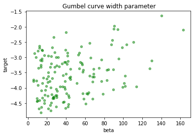

```python
df_final.plot(kind="scatter", x="beta", y="target", alpha=1/2, color='green')

plt.title(' Gumbel curve width parameter')
```